# Bioinformatics Project

Sergio Fernandez - Alessandro Mecchia - Paolo Nicolet

2026-01-16

# Imports and packages

```r
# Install BiocManager (once)
if (!requireNamespace("BiocManager", quietly = TRUE)) {
  install.packages("BiocManager")
}

# Helper installers
install_cran_if_missing <- function(pkgs) {
  pkgs <- unique(pkgs)
  to_install <- pkgs[!vapply(pkgs, requireNamespace, logical(1), quietly = TRUE)]
  if (length(to_install) > 0) install.packages(to_install, dependencies = TRUE)
  invisible(to_install)
}

install_bioc_if_missing <- function(pkgs) {
  pkgs <- unique(pkgs)
  to_install <- pkgs[!vapply(pkgs, requireNamespace, logical(1), quietly = TRUE)]
  if (length(to_install) > 0) BiocManager::install(to_install, ask = FALSE, update = FALSE)
  invisible(to_install)
}

## CRAN packages
install_cran_if_missing(c(
  "tidyverse",
  "pheatmap",
  "Seurat",
  "SeuratData",
  "visNetwork"
))

## Bioconductor packages
install_bioc_if_missing(c(
  "recount3",
  "org.Hs.eg.db",
  "ggtree",
  "clusterProfiler",
  "scRNAseq",
  "SingleCellExperiment",
  "SingleR",
  "celldex"
))
```

```r
library(recount3)
library(tidyr)
library(dplyr)
library(ggplot2)
library(plotly)
library(stringr)
library(edgeR)
library(pheatmap)
library(gplots)
library(RColorBrewer)
library(org.Hs.eg.db)
library(AnnotationDbi)
library(clusterProfiler)
library(org.Hs.eg.db)
library(enrichplot)
install.packages("visNetwork")
library(visNetwork)
library(scRNAseq)
library(Seurat)
library(SingleCellExperiment)
library(SingleR)
library(celldex)
```

# 1. Project Introduction

**Project Rules**

- The project must be completed in groups of three students.
- Each group will submit a notebook with code, discussion and everythink that is needed to run the notebook, one week before the exam date in January.
- During the exam, there will be a 10 minutes presentation followed by 20 minutes of interactive discussion with the instructors.
- All group members must be able to answer questions on any part of the project.

**Project Objectives**

Your work should demonstrate the ability to:

- Frame a biological problem computationally
- Define a biological question and explain how computational methods can address it.
- Identify and download appropriate RNA-seq and single-cell datasets.
- Apply computational techniques and interpret results in a biological context.
- Be prepared to explain and justify your choices during the exam.

**Required Components**

Your project must include:

1. Differential Gene Expression Analysis (Bulk RNA-seq)

- Perform differential expression analysis between two conditions (e.g., healthy vs diseased tissue).

2. Protein-Protein Interaction (PPI) Network Analysis

- Use the list of differentially expressed genes to explore protein-protein interaction networks.

3. Single-Cell RNA-seq Analysis

- Download a small dataset (e.g., lung tissue from healthy and diseased samples).
- Dimensionality reduction (PCA, UMAP).
- Cluster identification and annotation of major cell types.

# 2. Dataset Selection

```r
# List of available projects
projects <- available_projects()
projects
```

| project | organism | file_source | project_home | project_type | n_samples |
| --- | --- | --- | --- | --- | --- |
| SRP107565 | human | sra | data_sources/sra | data_sources | 216 |
| SRP149665 | human | sra | data_sources/sra | data_sources | 4 |
| SRP017465 | human | sra | data_sources/sra | data_sources | 23 |
| SRP119165 | human | sra | data_sources/sra | data_sources | 6 |
| SRP133965 | human | sra | data_sources/sra | data_sources | 12 |
| SRP096765 | human | sra | data_sources/sra | data_sources | 7 |
| SRP124965 | human | sra | data_sources/sra | data_sources | 12 |
| SRP189165 | human | sra | data_sources/sra | data_sources | 15 |
| SRP050365 | human | sra | data_sources/sra | data_sources | 10 |
| SRP123065 | human | sra | data_sources/sra | data_sources | 41 |

[output cut: 990 more lines]

```r
NA
```

The `available_projects()` function is used to retrieve all RNA-seq projects available in the recount3 database. As shown in the table, multiple projects are available, each containing RNA-seq data that can be used to perform gene expression analysis.

```r
# Filter by GTEx (normal tissues)
gtex_projects <- subset(projects, file_source == "gtex")

# Explore metadata
gtex_projects
```

|  | project | organism | file_source | project_home | project_type | n_samples |
| --- | --- | --- | --- | --- | --- | --- |
| 8678 | ADIPOSE_TISSUE | human | gtex | data_sources/gtex | data_sources | 1293 |
| 8679 | MUSCLE | human | gtex | data_sources/gtex | data_sources | 881 |
| 8680 | BLOOD_VESSEL | human | gtex | data_sources/gtex | data_sources | 1398 |
| 8681 | HEART | human | gtex | data_sources/gtex | data_sources | 942 |
| 8682 | OVARY | human | gtex | data_sources/gtex | data_sources | 195 |
| 8683 | UTERUS | human | gtex | data_sources/gtex | data_sources | 159 |
| 8684 | VAGINA | human | gtex | data_sources/gtex | data_sources | 173 |
| 8685 | BREAST | human | gtex | data_sources/gtex | data_sources | 482 |
| 8686 | SKIN | human | gtex | data_sources/gtex | data_sources | 1940 |
| 8687 | SALIVARY_GLAND | human | gtex | data_sources/gtex | data_sources | 178 |

[output cut: 22 more lines]

```r
NA
```

GTEx projects are selected because they provide RNA-seq data from healthy human tissues, which are used as controls for comparison with diseased samples.

```r
proj_info_pancreas <- subset(
    gtex_projects,
    project == "BRAIN" & project_type == "data_sources"
)

# Connet to GTEx project
rse_gene_BRAIN <- create_rse(proj_info_pancreas)
```

```
|--------------------------------------------------|
|==================================================|
```

```r
install.packages("visNetwork")
rse_gene_BRAIN
```

```
class: RangedSummarizedExperiment
dim: 63856 2931
metadata(8): time_created recount3_version ... annotation recount3_url
assays(1): raw_counts
rownames(63856): ENSG00000278704.1 ENSG00000277400.1 ... ENSG00000182484.15_PAR_Y ENSG00000227159.8_PAR_Y
rowData names(10): source type ... havana_gene tag
colnames(2931): GTEX-T6MN-0011-R1A-SM-32QOY.1 GTEX-WWYW-3126-SM-3NB39.1 ... GTEX-1O9I2-3026-SM-E76PX.1
  GTEX-1OJC4-2826-SM-E6CQX.1
colData names(198): rail_id external_id ... recount_seq_qc.errq BigWigURL
```

GTEx BRAIN data are used as a reference for normal gene expression in healthy brain tissue.

The dataset contains 63,856 genes and 2,931 samples, with gene annotations stored in `rowData` and 198 sample metadata variables available in `colData`.

```r
colnames(colData(rse_gene_BRAIN))
```

```
  [1] "rail_id"
  [2] "external_id"
  [3] "study"
  [4] "gtex.run_acc"
  [5] "gtex.subjid"
  [6] "gtex.sex"
  [7] "gtex.age"
  [8] "gtex.dthhrdy"
  [9] "gtex.sampid"
 [10] "gtex.smatsscr"
 [11] "gtex.smcenter"
 [12] "gtex.smpthnts"
 [13] "gtex.smrin"
 [14] "gtex.smts"
 [15] "gtex.smtsd"
```

[output cut: 183 more lines]

After defining the healthy reference using GTEx, we select tumor brain samples from TCGA. TCGA provides large-scale RNA-seq data from multiple cancer types and serves as the disease dataset for our analysis.

```r
# Filter by TCGA (the cancer genome atlas)
tcga_projects <- subset(projects, file_source== "tcga")

# Explore metadata
tcga_projects
```

|  | project | organism | file_source | project_home | project_type | n_samples |
| --- | --- | --- | --- | --- | --- | --- |
| 8710 | ACC | human | tcga | data_sources/tcga | data_sources | 79 |
| 8711 | BLCA | human | tcga | data_sources/tcga | data_sources | 433 |
| 8712 | BRCA | human | tcga | data_sources/tcga | data_sources | 1256 |
| 8713 | CESC | human | tcga | data_sources/tcga | data_sources | 309 |
| 8714 | CHOL | human | tcga | data_sources/tcga | data_sources | 45 |
| 8715 | COAD | human | tcga | data_sources/tcga | data_sources | 546 |
| 8716 | DLBC | human | tcga | data_sources/tcga | data_sources | 48 |
| 8717 | ESCA | human | tcga | data_sources/tcga | data_sources | 198 |
| 8718 | GBM | human | tcga | data_sources/tcga | data_sources | 175 |
| 8719 | HNSC | human | tcga | data_sources/tcga | data_sources | 548 |

[output cut: 23 more lines]

```r
proj_info_gbm <- subset(
  tcga_projects,
  project == "GBM" & project_type == "data_sources"
)

rse_gene_tcga <- create_rse(proj_info_gbm, type = "gene")

metadata_tcga <- colData(rse_gene_tcga)
all_cols <- colnames(metadata_tcga)

diagnosis_cols <- grep("^tcga\\.gdc_cases\\.diagnoses", all_cols, value = TRUE)
print(diagnosis_cols)
```

```
 [1] "tcga.gdc_cases.diagnoses.classification_of_tumor"   "tcga.gdc_cases.diagnoses.primary_diagnosis"
 [3] "tcga.gdc_cases.diagnoses.submitter_id"              "tcga.gdc_cases.diagnoses.tumor_stage"
 [5] "tcga.gdc_cases.diagnoses.age_at_diagnosis"          "tcga.gdc_cases.diagnoses.vital_status"
 [7] "tcga.gdc_cases.diagnoses.morphology"                "tcga.gdc_cases.diagnoses.days_to_death"
 [9] "tcga.gdc_cases.diagnoses.days_to_last_follow_up"    "tcga.gdc_cases.diagnoses.diagnosis_id"
[11] "tcga.gdc_cases.diagnoses.tissue_or_organ_of_origin" "tcga.gdc_cases.diagnoses.days_to_birth"
[13] "tcga.gdc_cases.diagnoses.treatments.submitter_id"   "tcga.gdc_cases.diagnoses.treatments.treatment_id"
```

```r
demo_cols <- grep("^tcga\\.gdc_cases\\.demographic", all_cols, value = TRUE)
print(demo_cols)
```

```
[1] "tcga.gdc_cases.demographic.updated_datetime" "tcga.gdc_cases.demographic.gender"
[3] "tcga.gdc_cases.demographic.submitter_id"     "tcga.gdc_cases.demographic.year_of_birth"
[5] "tcga.gdc_cases.demographic.race"             "tcga.gdc_cases.demographic.demographic_id"
[7] "tcga.gdc_cases.demographic.ethnicity"        "tcga.gdc_cases.demographic.year_of_death"
```

Here we select the TCGA-GBM project to represent tumor brain tissue. The resulting dataset contains 63,856 genes across 175 tumor samples, stored as raw counts with associated gene annotations (`rowData`) and sample metadata (`colData`).

```r
rse_gene_tcga
```

```
class: RangedSummarizedExperiment
dim: 63856 175
metadata(8): time_created recount3_version ... annotation recount3_url
assays(1): raw_counts
rownames(63856): ENSG00000278704.1 ENSG00000277400.1 ... ENSG00000182484.15_PAR_Y ENSG00000227159.8_PAR_Y
rowData names(10): source type ... havana_gene tag
colnames(175): 3b7f80e6-74a7-4da1-ac4b-c260b6be880a 97a8e2b1-059b-4527-8fb4-116f718ffd16 ...
  2dab6792-f9af-4565-bdd5-c9802f3132f4 c33edb64-c7b9-49a1-ae73-1d293f8522f6
colData names(937): rail_id external_id ... recount_seq_qc.errq BigWigURL
```

At this stage, we have defined the two datasets used in this project. GTEx BRAIN data represent gene expression in healthy brain tissue and are used as the normal reference condition. TCGA GBM data represent tumor brain tissue and define the diseased condition.

## 2.1. Dataset Reduction

Before performing differential gene expression analysis, we need to address an unbalanced dataset problem. As introduced earlier, the GTEx BRAIN dataset includes approximately 3,000 normal samples, while the TCGA GBM dataset contains only 175 tumor samples.

This strong imbalance between the two conditions can introduce bias in downstream analyses.

Therefore, this imbalance must be addressed before proceeding with differential gene expression analysis.

```r
md_gtex <- as.data.frame(colData(rse_gene_BRAIN))
md_tcga <- as.data.frame(colData(rse_gene_tcga))
```

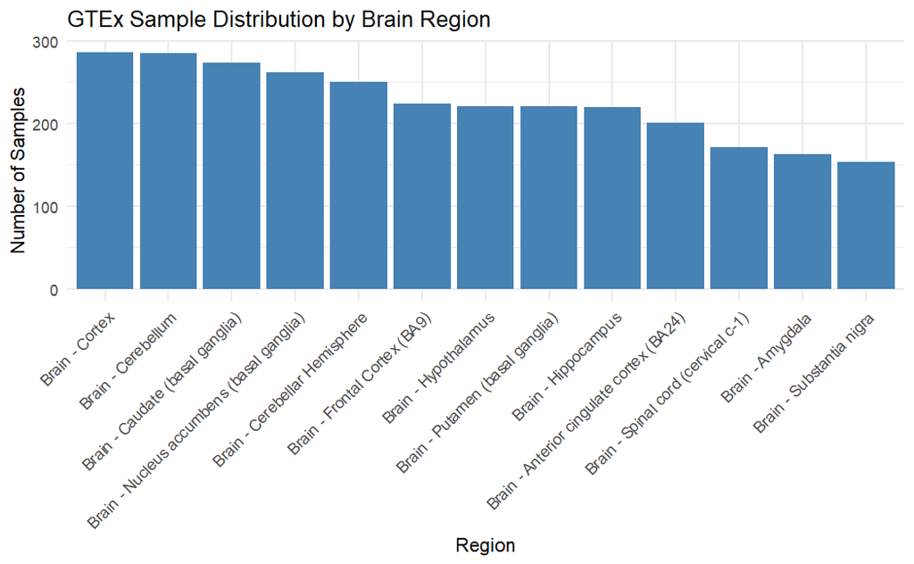

```r
gtex_counts <- as.data.frame(table(md_gtex$gtex.smtsd))
colnames(gtex_counts) <- c("Region", "Count")

ggplot(gtex_counts, aes(x = reorder(Region, -Count), y = Count)) +
  geom_bar(stat = "identity", fill = "steelblue") +
  theme_minimal() +
  theme(axis.text.x = element_text(angle = 45, hjust = 1)) +
  labs(title = "GTEx Sample Distribution by Brain Region",
       x = "Region",
       y = "Number of Samples")
```

The plot shows that GTEx samples are distributed across different brain regions. Brain cortex is the most represented region, with about 300 samples.

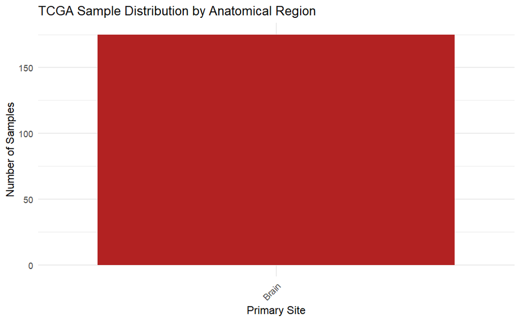

```r
tcga_site_counts <- as.data.frame(table(md_tcga$tcga.gdc_cases.project.primary_site))
colnames(tcga_site_counts) <- c("Region", "Count")

ggplot(tcga_site_counts, aes(x = reorder(Region, -Count), y = Count)) +
  geom_bar(stat = "identity", fill = "firebrick") +
  theme_minimal() +
  theme(axis.text.x = element_text(angle = 45, hjust = 1)) +
  labs(title = "TCGA Sample Distribution by Anatomical Region",
       x = "Primary Site",
       y = "Number of Samples")
```

TCGA GBM samples are not stratified by brain region, preventing a region-specific comparison. For this reason, GTEx healthy samples are filtered to the Brain – Cortex, the most biologically relevant region for Glioblastoma and the most represented region in GTEx. This choice results in a more balanced and biologically consistent comparison.

```r
rse_gene_BRAIN <- rse_gene_BRAIN[, rse_gene_BRAIN$gtex.smtsd == "Brain - Cortex"]
```

# 3. Data Exploration

Since the data were obtained from two different sources, GTEx for healthy samples and TCGA for tumor samples, it is necessary to verify that the two populations are comparable. To this end, we explore key sample-level characteristics that should be broadly similar between the two datasets. In particular, we focus on biological variables (such as age and sex) and technical quality metrics.

## 3.1. Age distribution

```r
age_gtex <- md_gtex$gtex.age
head(age_gtex)
```

```
[1] "50-59" "50-59" "50-59" "40-49" "50-59" "60-69"
```

```r
age_tcga <- md_tcga$tcga.gdc_cases.diagnoses.age_at_diagnosis
head(age_tcga)
```

```
[1] 26796 21384 19053 23343 20159 17880
```

```r
gtex_bins   <- c(20,30,40,50,60,70,80, Inf)
gtex_labels <- c("20-29","30-39","40-49","50-59","60-69","70-79","80+")

df_age_perc <- bind_rows(
  data.frame(
    age_bin = factor(md_gtex$gtex.age, levels = gtex_labels),
    dataset = "GTEx"
  ),
  data.frame(
    age = as.numeric(md_tcga$tcga.gdc_cases.diagnoses.age_at_diagnosis) / 365.25,
    dataset = "TCGA"
  ) %>%
    mutate(age_bin = cut(age, breaks = gtex_bins, labels = gtex_labels, right = FALSE))
) %>%
  filter(!is.na(age_bin)) %>%
  count(dataset, age_bin) %>%
  group_by(dataset) %>%
  mutate(percent = n / sum(n) * 100) %>%
  ungroup()
```

```r
p <- ggplot(
  df_age_perc,
  aes(x = age_bin, y = percent, fill = dataset)
) +
  geom_col(position = "dodge") +
  labs(
    x = "Age range (years)",
    y = "Percentage of samples",
    title = "Normalized age distribution: GTEx vs TCGA"
  ) +
theme_minimal() +
  theme(axis.text.x = element_text(angle = 45, hjust = 1))

ggplotly(p)
```

[interactive chart not shown]

```r
NA
```

This plot shows the normalized age distribution for GTEx (healthy) and TCGA (tumor). Overall, the two datasets have broadly comparable age ranges, although some bins differ in relative frequency.

## 3.2. Sex Distribution

```r
sex_gtex <- md_gtex$gtex.sex %>%
  recode(
    `1` = "Male",
    `2` = "Female"
  )

sex_tcga <- md_tcga$tcga.gdc_cases.demographic.gender
```

```r
df_sex <- bind_rows(
  data.frame(
    sex = sex_gtex,
    dataset = "GTEx"
  ),
  data.frame(
    sex = sex_tcga,
    dataset = "TCGA"
  )
) %>%
  filter(!is.na(sex)) %>%
  mutate(sex = str_to_title(sex)) %>%
  count(dataset, sex) %>%
  group_by(dataset) %>%
  mutate(percent = n / sum(n) * 100) %>%
  ungroup()
```

```r
p_sex <- ggplot(
  df_sex,
  aes(x = sex, y = percent, fill = dataset)
) +
  geom_col(position = "dodge") +
  labs(
    x = "Sex",
    y = "Percentage of samples",
    title = "Sex distribution: GTEx vs TCGA"
  ) +
  theme_minimal()

ggplotly(p_sex)
```

[interactive chart not shown]

```r
NA
```

Also in this case, we can observe that both datasets show similar sex proportions.

## 3.3. RNA Quality

```r
df_qc_long <- bind_rows(
  md_gtex %>%
    transmute(
      dataset = "GTEx",
      avgq = recount_seq_qc.avgq,
      errq = recount_seq_qc.errq
    ),
  md_tcga %>%
    transmute(
      dataset = "TCGA",
      avgq = recount_seq_qc.avgq,
      errq = recount_seq_qc.errq
    )
) %>%
  pivot_longer(
    cols = c(avgq, errq),
    names_to = "metric",
    values_to = "value"
  ) %>%
  filter(!is.na(value))
```

The metrics used here are RNA-seq quality control measures provided by the recount3 pipeline. The average base quality (`avgq`) represents the mean sequencing quality score across all bases in a sample, with higher values indicating more reliable base calls. The base error rate (`errq`) estimates the frequency of sequencing errors, where lower values correspond to higher sequencing accuracy.

```r
p_qc_facet <- ggplot(
  df_qc_long,
  aes(x = dataset, y = value, fill = dataset)
) +
  geom_boxplot(outlier.alpha = 0.3) +
  facet_wrap(~ metric, scales = "free_y",
             labeller = as_labeller(c(
               avgq = "Average base quality (avgq)",
               errq = "Base error rate (errq)"
             ))) +
  labs(
    x = "",
    y = "",
    title = "RNA-seq quality metrics comparison: GTEx vs TCGA"
  ) +
  theme_minimal() +
  theme(
    legend.position = "none",
    strip.text = element_text(face = "bold")
  )

ggplotly(p_qc_facet)
```

[interactive chart not shown]

```r
NA
```

While some outliers are present, most samples show acceptable average base quality and error rate values. Overall, the RNA-seq quality of both datasets is suitable for downstream analysis.

# 4. Different Gene Expression Analysis (Bulk RNA-seq)

As a first step in the differential gene expression analysis, we extract gene-level count matrices from the GTEx and TCGA datasets. To ensure comparability between the two sources, we retain only genes that are present in both datasets and build a unified count matrix by combining healthy and tumor samples.

```r
counts_gtex <- transform_counts(rse_gene_BRAIN)
counts_tcga <- transform_counts(rse_gene_tcga)

common_genes <- intersect(rownames(counts_gtex), rownames(counts_tcga))

counts_gtex2 <- counts_gtex[common_genes, ]
counts_tcga2 <- counts_tcga[common_genes, ]

count_matrix <- cbind(counts_gtex2, counts_tcga2)
```

```r
count_matrix <- as.data.frame(count_matrix)
head(count_matrix)
```

|  | GTEX-WWYW-3126-SM-3NB39.1 | GTEX-WVLH-3026-SM-3MJG9.1 | GTEX-14BIM-3026-SM-7EWCY.1 | GTEX-16GPK-3026-SM-79ON9.1 | GTEX-18465-3026-SM-7LG6Y.1 | GTEX-1GN73-3126-SM-9KNTY.1 | GTEX-1LKK1-3126-SM-EWRNY.1 | GTEX-1R9K4-3126-SM-DTX9Y.1 | GTEX-13OW8-2826-SM-5L3GC.1 | GTEX-13VXU-2926-SM-5LU5C.1 | GTEX-144FL-3026-SM-5O99C.1 | GTEX-12WSA-2926-SM-5EQ4D.1 | GTEX-11DXY-3226-SM-5GIDE.1 | GTEX-13QIC-2926-SM-5J2NF.1 | GTEX-132Q8-3026-SM-5PNVG.1 | GTEX-13JVG-3126-SM-5L3FH.1 | GTEX-ZDXO-2126-SM-4WKFI.1 | GTEX-11ZUS-2926-SM-5FQSL.1 | GTEX-11EI6-3026-SM-5GZZO.1 | GTEX-11GSP-3226-SM-5986O.1 | GTEX-11TTK-2926-SM-5PNYP.1 | GTEX-12ZZW-2926-SM-5LZUP.1 | GTEX-13PVQ-3026-SM-5SI93.1 | GTEX-13O3Q-2926-SM-5KM45.1 | GTEX-11O72-2926-SM-5BC4V.1 | GTEX-11EMC-3226-SM-5EGKW.1 | GTEX-13OVJ-2826-SM-5L3GW.1 | GTEX-11OF3-2926-SM-5HL78.1 | GTEX-X585-3026-SM-46MWF.1 | … |
| --- | --- | --- | --- | --- | --- | --- | --- | --- | --- | --- | --- | --- | --- | --- | --- | --- | --- | --- | --- | --- | --- | --- | --- | --- | --- | --- | --- | --- | --- | --- |
| ENSG00000278704.1 | 0 | 0 | 0 | 0 | 0 | 0 | 0 | 0 | 0 | 0 | 0 | 0 | 0 | 0 | 0 | 0 | 0 | 0 | 0 | 0 | 0 | 0 | 0 | 0 | 0 | 0 | 0 | 0 | 0 | … |
| ENSG00000277400.1 | 0 | 0 | 0 | 0 | 0 | 0 | 0 | 0 | 0 | 0 | 0 | 0 | 0 | 0 | 0 | 0 | 0 | 0 | 0 | 0 | 0 | 0 | 0 | 0 | 0 | 0 | 0 | 0 | 0 | … |
| ENSG00000274847.1 | 0 | 0 | 0 | 0 | 0 | 0 | 0 | 0 | 0 | 0 | 0 | 0 | 0 | 0 | 0 | 0 | 0 | 0 | 0 | 0 | 0 | 0 | 0 | 0 | 0 | 0 | 0 | 0 | 0 | … |
| ENSG00000277428.1 | 0 | 0 | 0 | 0 | 0 | 0 | 0 | 0 | 0 | 0 | 0 | 0 | 0 | 0 | 0 | 0 | 0 | 0 | 0 | 0 | 0 | 0 | 0 | 0 | 0 | 0 | 0 | 0 | 0 | … |
| ENSG00000276256.1 | 0 | 0 | 0 | 0 | 0 | 0 | 0 | 0 | 0 | 0 | 0 | 0 | 0 | 0 | 0 | 0 | 0 | 0 | 0 | 0 | 0 | 0 | 0 | 0 | 0 | 0 | 0 | 0 | 0 | … |
| ENSG00000278198.1 | 0 | 0 | 0 | 0 | 0 | 0 | 0 | 0 | 0 | 0 | 0 | 0 | 0 | 0 | 0 | 0 | 0 | 0 | 0 | 0 | 0 | 0 | 0 | 0 | 0 | 0 | 0 | 0 | 0 | … |

The resulting table represents a gene-by-sample count matrix, where rows correspond to genes (Ensembl IDs) and columns correspond to individual samples from both GTEx and TCGA. Each value indicates the raw expression count of a given gene in a specific sample and constitutes the input for downstream normalization and differential expression testing.

## 4.1. Quality Control

### 4.1.1. Normalization

**Counts Per Million (CPM)**

For a given gene *i* in sample *j*, the CPM is calculated as:

$$\text{CPM}_{ij} = \left( \frac{\text{Raw count}_{ij}}{\sum_{k=1}^{N}
\text{Raw count}_{kj}} \right) \times 10^6$$

Where:

- $\text{Raw count}_{ij}$: number of reads for gene *i* in sample *j*
- ${\sum_{k=1}^{N} \text{Raw count}_{kj}}$: total number of reads for all genes in sample *j*
- The multiplication by $ 10^6 $ scales the expression to “per million” units

```r
# Define group labels (healthy vs tumor)
group <- factor(c(
  rep("GTEx", ncol(counts_gtex2)),
  rep("TCGA", ncol(counts_tcga2))
))

# Create edgeR object
dge <- DGEList(counts = count_matrix, group = group)

# Compute CPM values
CPMs <- edgeR::cpm(dge)
head(as.data.frame(CPMs)[, 1:5])
```

|  | GTEX-WWYW-3126-SM-3NB39.1 | GTEX-WVLH-3026-SM-3MJG9.1 | GTEX-14BIM-3026-SM-7EWCY.1 | GTEX-16GPK-3026-SM-79ON9.1 | GTEX-18465-3026-SM-7LG6Y.1 |
| --- | --- | --- | --- | --- | --- |
| ENSG00000278704.1 | 0 | 0 | 0 | 0 | 0 |
| ENSG00000277400.1 | 0 | 0 | 0 | 0 | 0 |
| ENSG00000274847.1 | 0 | 0 | 0 | 0 | 0 |
| ENSG00000277428.1 | 0 | 0 | 0 | 0 | 0 |
| ENSG00000276256.1 | 0 | 0 | 0 | 0 | 0 |
| ENSG00000278198.1 | 0 | 0 | 0 | 0 | 0 |

```r
NA
```

**Filtering lowly expressed genes**

Genes with very low counts across samples provide little evidence for differential expression and increase noise and the multiple-testing burden. For this reason, lowly expressed genes are removed prior to model fitting.

In this analysis, expression filtering is performed using the `filterByExpr()` function from the edgeR package. Rather than applying a fixed CPM threshold, this approach determines whether a gene has sufficient expression to be statistically testable, taking into account library sizes and the experimental group structure (GTEx vs TCGA).

This strategy avoids the removal of condition-specific genes and improves the statistical power and robustness of downstream differential expression analysis.

```r
# Filter lowly expressed genes using study design (recommended)
keep <- filterByExpr(dge, group = group)

# Apply filter and recompute library sizes
dge <- dge[keep, , keep.lib.sizes = FALSE]

dim(dge)
```

```
[1] 25065   461
```

```r
counts_filtered <- as.data.frame(dge$counts)

head(counts_filtered)
```

|  | GTEX-WWYW-3126-SM-3NB39.1 | GTEX-WVLH-3026-SM-3MJG9.1 | GTEX-14BIM-3026-SM-7EWCY.1 | GTEX-16GPK-3026-SM-79ON9.1 | GTEX-18465-3026-SM-7LG6Y.1 | GTEX-1GN73-3126-SM-9KNTY.1 | GTEX-1LKK1-3126-SM-EWRNY.1 | GTEX-1R9K4-3126-SM-DTX9Y.1 | GTEX-13OW8-2826-SM-5L3GC.1 | GTEX-13VXU-2926-SM-5LU5C.1 | GTEX-144FL-3026-SM-5O99C.1 | GTEX-12WSA-2926-SM-5EQ4D.1 | GTEX-11DXY-3226-SM-5GIDE.1 | GTEX-13QIC-2926-SM-5J2NF.1 | GTEX-132Q8-3026-SM-5PNVG.1 | GTEX-13JVG-3126-SM-5L3FH.1 | GTEX-ZDXO-2126-SM-4WKFI.1 | GTEX-11ZUS-2926-SM-5FQSL.1 | GTEX-11EI6-3026-SM-5GZZO.1 | GTEX-11GSP-3226-SM-5986O.1 | GTEX-11TTK-2926-SM-5PNYP.1 | GTEX-12ZZW-2926-SM-5LZUP.1 | GTEX-13PVQ-3026-SM-5SI93.1 | GTEX-13O3Q-2926-SM-5KM45.1 | GTEX-11O72-2926-SM-5BC4V.1 | GTEX-11EMC-3226-SM-5EGKW.1 | GTEX-13OVJ-2826-SM-5L3GW.1 | GTEX-11OF3-2926-SM-5HL78.1 | GTEX-X585-3026-SM-46MWF.1 | … |
| --- | --- | --- | --- | --- | --- | --- | --- | --- | --- | --- | --- | --- | --- | --- | --- | --- | --- | --- | --- | --- | --- | --- | --- | --- | --- | --- | --- | --- | --- | --- |
| ENSG00000278267.1 | 32 | 20 | 36 | 15 | 23 | 17 | 31 | 22 | 22 | 16 | 29 | 29 | 22 | 21 | 23 | 15 | 19 | 28 | 18 | 11 | 14 | 23 | 16 | 16 | 35 | 23 | 20 | 38 | 21 | … |
| ENSG00000227232.5 | 707 | 632 | 878 | 402 | 636 | 706 | 732 | 551 | 641 | 657 | 778 | 669 | 707 | 545 | 725 | 437 | 726 | 738 | 511 | 494 | 577 | 635 | 737 | 496 | 812 | 653 | 742 | 1245 | 722 | … |
| ENSG00000243485.5 | 16 | 12 | 22 | 9 | 18 | 11 | 10 | 13 | 15 | 21 | 15 | 8 | 13 | 11 | 27 | 6 | 13 | 33 | 14 | 10 | 17 | 11 | 4 | 16 | 13 | 10 | 8 | 16 | 12 | … |
| ENSG00000238009.6 | 13 | 18 | 23 | 10 | 19 | 38 | 12 | 58 | 32 | 18 | 16 | 13 | 32 | 21 | 25 | 12 | 17 | 35 | 12 | 11 | 19 | 13 | 15 | 27 | 20 | 21 | 40 | 42 | 41 | … |
| ENSG00000233750.3 | 10 | 7 | 22 | 6 | 9 | 19 | 10 | 10 | 16 | 8 | 20 | 11 | 11 | 12 | 12 | 4 | 12 | 6 | 7 | 7 | 9 | 6 | 4 | 13 | 14 | 11 | 6 | 30 | 19 | … |
| ENSG00000268903.1 | 79 | 35 | 133 | 40 | 37 | 80 | 75 | 79 | 80 | 40 | 104 | 63 | 25 | 86 | 106 | 33 | 99 | 60 | 30 | 65 | 46 | 48 | 55 | 59 | 116 | 43 | 92 | 49 | 180 | … |

**Normalization for Composition Bias (TMM)**

While CPM normalization accounts for differences in sequencing depth (library size), it does not address **composition bias**. Composition bias occurs when a small number of highly expressed genes dominate the total pool of RNA in a library, artificially deflating the relative counts of all other genes.

We apply **TMM** normalization instead of **TPM** because:

- **TPM** is for comparing different genes **within** one sample (it corrects for gene length).
- **TMM** is for comparing the same gene **between** different samples (Healthy vs. Tumor). It corrects for **composition bias**, ensuring that a few highly expressed genes do not skew the results for the entire library.

```r
# Calculate TMM normalization factors
dge <- calcNormFactors(dge, method = "TMM")
```

```r
# Check normalization factors (should be around 1)
head(dge$samples)
```

|  | group | lib.size | norm.factors |
| --- | --- | --- | --- |
| GTEX-WWYW-3126-SM-3NB39.1 | GTEx | 38449892 | 1.0121573 |
| GTEX-WVLH-3026-SM-3MJG9.1 | GTEx | 38465028 | 0.9969780 |
| GTEX-14BIM-3026-SM-7EWCY.1 | GTEx | 38329809 | 1.1004245 |
| GTEX-16GPK-3026-SM-79ON9.1 | GTEx | 37778549 | 0.7554210 |
| GTEX-18465-3026-SM-7LG6Y.1 | GTEx | 39119200 | 0.9951576 |
| GTEX-1GN73-3126-SM-9KNTY.1 | GTEx | 37135512 | 0.9722533 |

The table reports library sizes and TMM normalization factors for each sample. Normalization factors close to 1 indicate that no extreme composition bias is present.

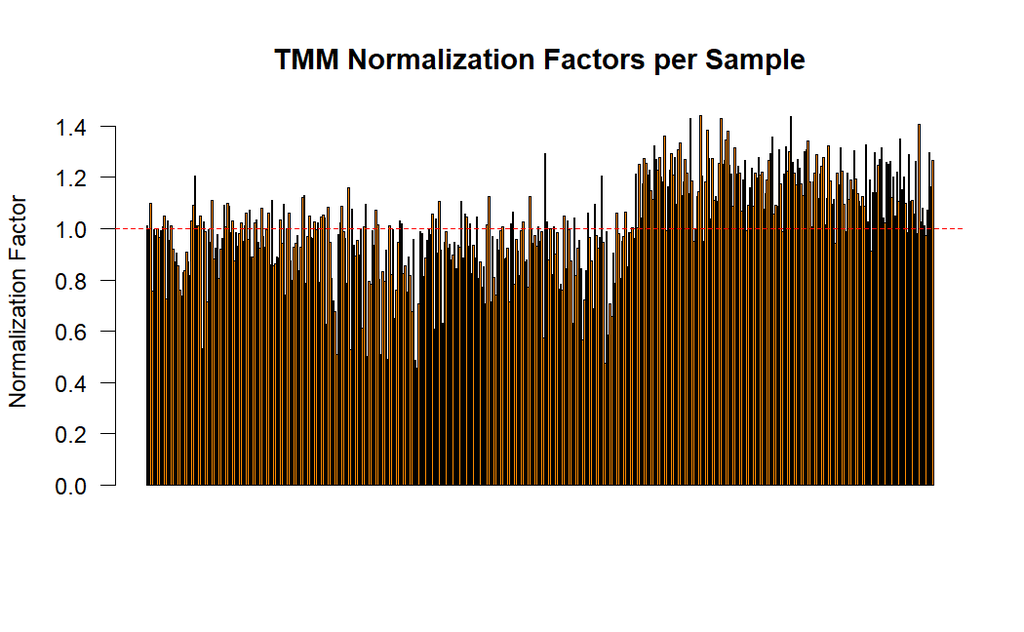

```r
barplot(
  dge$samples$norm.factors,
  las = 1,
  col = "darkorange",
  main = "TMM Normalization Factors per Sample",
  ylab = "Normalization Factor"
)

abline(h = 1, col = "red", lty = 2)
```

```r
NA
NA
```

### 4.1.2. Unsupervised Clustering

To explore the global structure of the data, we perform an unsupervised analysis using PCA. We compute log-transformed CPM values from the filtered and TMM-normalized count matrix, then run PCA on the transposed matrix (samples as observations, genes as features). Finally, we attach sample metadata (dataset, sex, age, and RNA quality) .

```r
logcounts_all <- edgeR::cpm(dge, log = TRUE)
pca_res <- prcomp(t(logcounts_all), scale. = TRUE)
pca_df <- as.data.frame(pca_res$x)

samples_gtex <- colnames(counts_gtex2)
samples_tcga <- colnames(counts_tcga2)

pca_df$Group <- c(rep("GTEx", length(samples_gtex)), rep("TCGA", length(samples_tcga)))
pca_df$SampleID <- rownames(pca_df)

pca_df$Sex <- c(
  md_gtex[samples_gtex, ]$gtex.sex %>% recode(`1` = "Male", `2` = "Female"),
  md_tcga[samples_tcga, ]$tcga.gdc_cases.demographic.gender %>% str_to_title()
)

pca_df$Age <- c(
  md_gtex[samples_gtex, ]$gtex.age,
  as.character(round(as.numeric(md_tcga[samples_tcga, ]$tcga.gdc_cases.diagnoses.age_at_diagnosis) / 365.25, 0))
)

pca_df$AvgQ <- c(md_gtex[samples_gtex, ]$recount_seq_qc.avgq,
                 md_tcga[samples_tcga, ]$recount_seq_qc.avgq)

# Variabile numerica per il menu a tendina
pca_df$AgeNumeric <- as.numeric(gsub("[^0-9]", "", pca_df$Age))
```

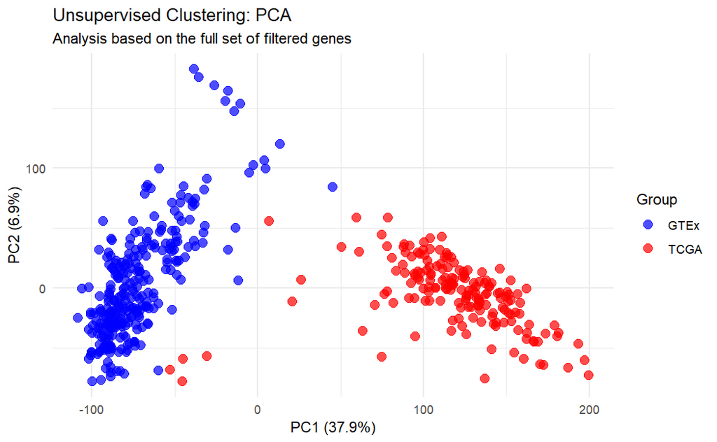

```r
ggplot(pca_df, aes(x = PC1, y = PC2, color = Group)) +
  geom_point(size = 3, alpha = 0.7) +
  theme_minimal() +
  scale_color_manual(values = c("GTEx" = "blue", "TCGA" = "red")) +
  labs(title = "Unsupervised Clustering: PCA",
       subtitle = "Analysis based on the full set of filtered genes",
       x = paste0("PC1 (", round(100*summary(pca_res)$importance[2,1], 1), "%)"),
       y = paste0("PC2 (", round(100*summary(pca_res)$importance[2,2], 1), "%)"))
```

As expected, we observe a clear separation between GTEx and TCGA samples, reflecting the strong transcriptional differences between healthy brain tissue and glioblastoma. This separation arises from widespread changes in gene expression associated with tumor biology, including altered cell proliferation, metabolism, and signaling pathways.

Having obtained this first unsupervised overview, the next step is to investigate whether additional hidden patterns are present. In particular, we assess whether patient-related variables such as age, sex, or RNA quality metrics contribute to the observed variability or introduce potential confounding effects.

```r
p_inter <- plot_ly(pca_df, x = ~PC1, y = ~PC2,
             symbol = ~Group,
             symbols = c('circle', 'x'),
             text = ~paste("Sample:", SampleID, "<br>Sex:", Sex, "<br>Age:", Age, "<br>AvgQ:", AvgQ),
             type = "scatter", mode = "markers",
             marker = list(size = 10, opacity = 0.8)) %>%
  layout(
    title = "Interactive PCA: Metadata Exploration",
    xaxis = list(title = "PC1"),
    yaxis = list(title = "PC2"),
    updatemenus = list(
      list(
        x = 0.05, y = 1, xanchor = "left", yanchor = "top",
        buttons = list(
          list(method = "restyle",
               args = list("marker.color", list(ifelse(pca_df$Group == "GTEx", "blue", "red"))),
               label = "Color by Dataset"),
          list(method = "restyle",
               args = list("marker.color", list(ifelse(pca_df$Sex == "Male", "#1f77b4", "#e377c2"))),
               label = "Color by Sex"),
          list(method = "restyle",
               args = list("marker.color", list(pca_df$AgeNumeric),
                           "marker.colorscale", "Viridis", "marker.showscale", TRUE),
               label = "Color by Age"),
          list(method = "restyle",
               args = list("marker.color", list(pca_df$AvgQ),
                           "marker.colorscale", "Plasma", "marker.showscale", TRUE),
               label = "Color by RNA Quality")
        )
      )
    )
  )

p_inter
```

[interactive chart not shown]

By exploring the PCA using different coloring schemes, no clear clustering patterns are observed with respect to age, sex, or RNA quality metrics.

```r
# We estimate the variance for each row in the logcounts matrix
var_genes <- apply(logcounts_all, 1, var)

# Get the gene names for the top 100 most variable genes
select_var <- names(sort(var_genes, decreasing=TRUE))[1:100]

# Keep the expression values for the top 100 variable genes
highly_variable_lcpm <- logcounts_all[select_var,]
dim(highly_variable_lcpm)
```

```
[1] 100 461
```

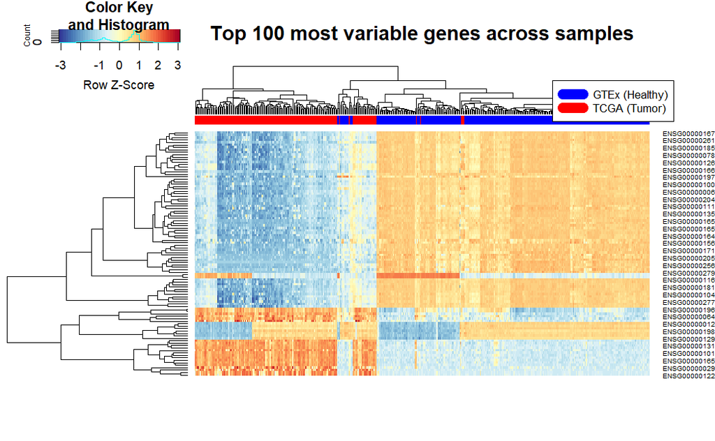

```r
# Setup colors
mypalette <- brewer.pal(11,"RdYlBu")
morecols <- colorRampPalette(mypalette)

# Assign blue and red to different datasets
col.cell <- ifelse(pca_df$Group == "GTEx", "blue", "red")


heatmap.2(highly_variable_lcpm,
          col=rev(morecols(50)),
          trace="none",
          main="Top 100 most variable genes across samples",
          ColSideColors=col.cell,
          scale="row",
          labCol="",      # Hide sample names for clarity
          cexRow=0.6,     # Adjust gene name size
          srtCol=45
)

# Add Legend
legend("topright",
       legend = c("GTEx (Healthy)", "TCGA (Tumor)"),
       col = c("blue", "red"),
       lty = 1,
       lwd = 10,
       cex = 0.7)
```

This heatmap is used to visualize the expression patterns of the most variable genes across samples and to assess whether they reflect the expected biological separation. As expected, the samples cluster according to their condition, with a clear separation between GTEx (healthy) and TCGA (tumor), consistent with the PCA results.

Expression values are shown as row Z-scores: warm colors indicate higher relative expression of a gene in a sample, while cool colors indicate lower relative expression.

```r
# Get the gene names for the top 100 LEAST variable genes (lowest variance)
select_var_low <- names(sort(var_genes, decreasing = FALSE))[1:100]

# Keep the expression values for the top 100 least variable genes
least_variable_lcpm <- logcounts_all[select_var_low,]
dim(least_variable_lcpm)
```

```
[1] 100 461
```

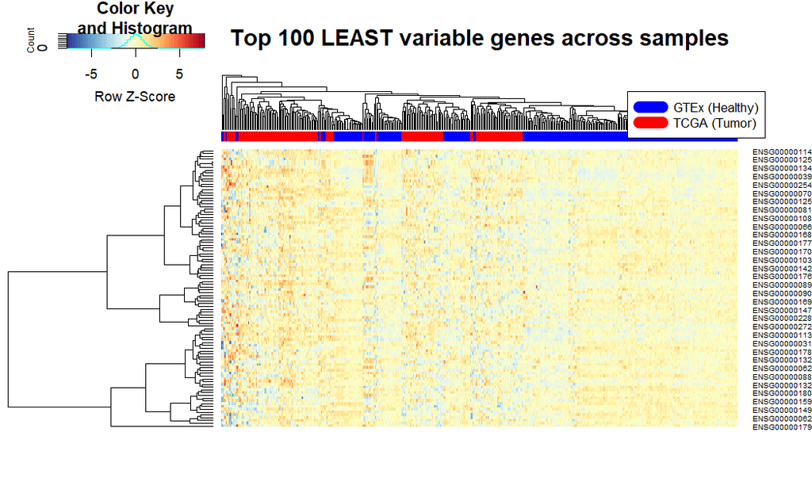

```r
# Setup colors
mypalette <- brewer.pal(11,"RdYlBu")
morecols <- colorRampPalette(mypalette)

# Assign blue and red to different datasets
col.cell <- ifelse(pca_df$Group == "GTEx", "blue", "red")


heatmap.2(least_variable_lcpm,
          col=rev(morecols(50)),
          trace="none",
          main="Top 100 LEAST variable genes across samples",
          ColSideColors=col.cell,
          scale="row",
          labCol="",      # Hide sample names for clarity
          cexRow=0.6,     # Adjust gene name size
          srtCol=45
)

# Add Legend
legend("topright",
       legend = c("GTEx (Healthy)", "TCGA (Tumor)"),
       col = c("blue", "red"),
       lty = 1,
       lwd = 10,
       cex = 0.7)
```

The least variable genes show stable expression and do not separate healthy and tumor samples.

## 4.2. DE Analysis

After completing the unsupervised analysis, we now move to differential gene expression (DE) analysis. The objective of this section is to identify genes whose expression levels differ significantly between healthy brain tissue (GTEx) and glioblastoma samples (TCGA), providing insights into the molecular mechanisms underlying the disease.

**Count the reads for any sample**

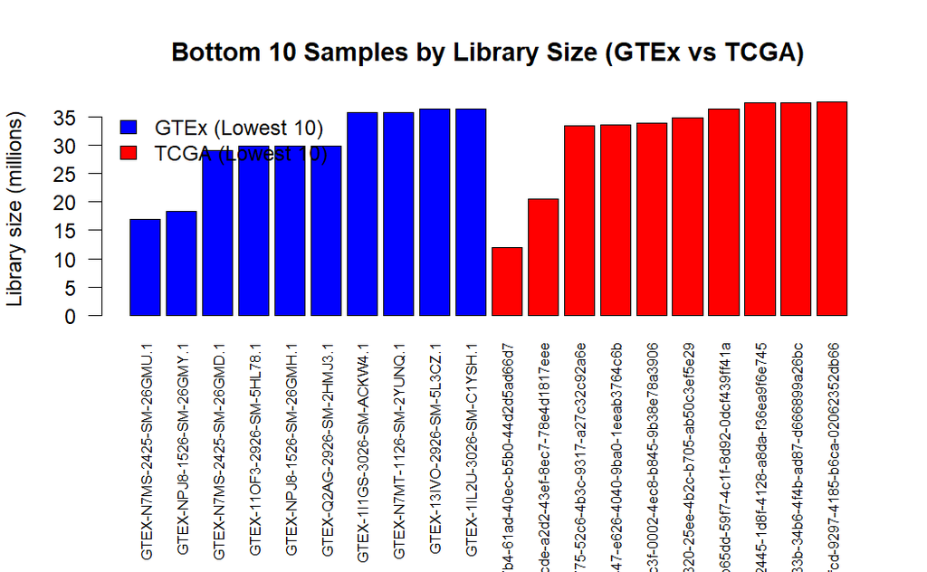

```r
idx_gtex <- 1:ncol(counts_gtex2)
idx_tcga <- (ncol(counts_gtex2) + 1):(ncol(counts_gtex2) + ncol(counts_tcga2))

lib_sizes_gtex <- dge$samples$lib.size[idx_gtex]
names(lib_sizes_gtex) <- colnames(dge)[idx_gtex]
low_10_gtex <- sort(lib_sizes_gtex)[1:10]

lib_sizes_tcga <- dge$samples$lib.size[idx_tcga]
names(lib_sizes_tcga) <- colnames(dge)[idx_tcga]
low_10_tcga <- sort(lib_sizes_tcga)[1:10]

low_20_total <- c(low_10_gtex, low_10_tcga)

par(mar = c(10, 4, 4, 2))
barplot(low_20_total / 1e6,
        las = 2,
        ylab = "Library size (millions)",
        main = "Bottom 10 Samples by Library Size (GTEx vs TCGA)",
        col = c(rep("blue", 10), rep("red", 10)),
        cex.names = 0.7) # Rimpicciolisce i nomi delle colonne per farli stare

legend("topleft", legend = c("GTEx (Lowest 10)", "TCGA (Lowest 10)"),
       fill = c("blue", "red"), bty = "n")
```

```r
NA
NA
```

This plot shows the library size, defined as the total number of reads mapped for each sample. Here, we visualize the samples with the lowest library sizes from GTEx and TCGA to assess potential sequencing depth issues.

*Plot the distribution of expression for sample*

```r
sample_means <- colMeans(CPMs)

idx_gtex <- 1:ncol(counts_gtex2)
idx_tcga <- (ncol(counts_gtex2) + 1):(ncol(counts_gtex2) + ncol(counts_tcga2))

low_10_gtex_names <- names(sort(sample_means[idx_gtex])[1:10])
low_10_tcga_names <- names(sort(sample_means[idx_tcga])[1:10])

logcounts <- edgeR::cpm(count_matrix, log=TRUE)
sub_logcounts <- logcounts[, c(low_10_gtex_names, low_10_tcga_names)]
```

```r
par(mar = c(10, 4, 4, 2))
boxplot(sub_logcounts,
        las = 2,
        main = "Boxplot of Log2-CPMs (Bottom 10 Samples per Group)",
        ylab = "Log2 Counts per Million",
        col = c(rep("blue", 10), rep("red", 10)),
        names = c(paste0("GTEx_", 1:10), paste0("TCGA_", 1:10)))

abline(h = median(logcounts), col = "darkgreen", lwd = 2, lty = 2)
```

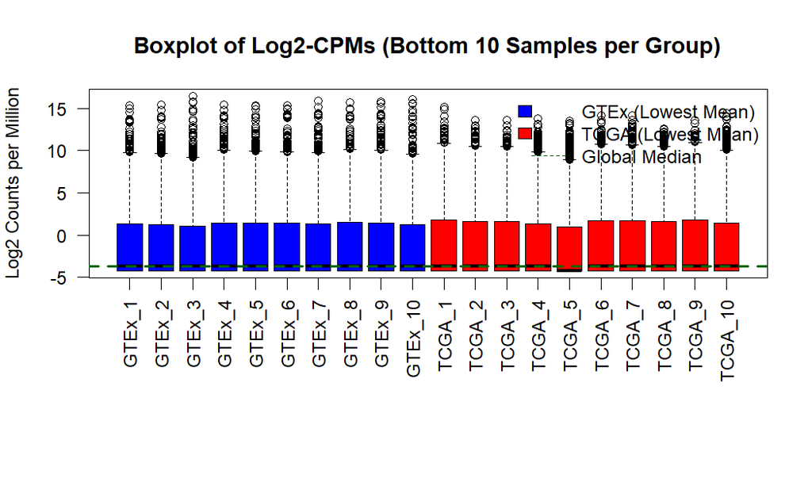

```r
legend("topright", legend = c("GTEx (Lowest Mean)", "TCGA (Lowest Mean)", "Global Median"),
       fill = c("blue", "red", NA), border = c("black", "black", NA),
       lty = c(NA, NA, 2), col = c(NA, NA, "darkgreen"), bty = "n")
```

Despite minor differences, the overall log2-CPM distributions are comparable between GTEx and TCGA samples and centered around similar values. This indicates that low library size does not introduce strong biases.

### 4.2.1. Naive Approach

In this first (naive) approach, we estimate differential expression by comparing GTEx vs TCGA using a simple gene-wise t-test on log2-CPM values. This provides an intuitive baseline to rank genes by statistical significance and effect size, before moving to the edgeR model-based method.

```r
# Save the normalized data into a new variable
simple_deg <- logcounts_all

# Gather the columns corresponding to the 2 groups
gtex_cols <- which(pca_df$Group == "GTEx")
tcga_cols <- which(pca_df$Group == "TCGA")
```

**Perform a t-test on the groups and optain the p-value**

The p-value quantifies the evidence against the null hypothesis that a gene has equal mean expression in GTEx and TCGA samples.

```r
p_values <- apply(simple_deg, 1, function(x) {
  t.test(x[gtex_cols], x[tcga_cols])$p.value
})
```

**Calculate foldchange**

Fold change quantifies the magnitude and direction of gene expression differences between conditions, complementing statistical significance with biological relevance.

```r
log2FC <- rowMeans(simple_deg[, tcga_cols]) - rowMeans(simple_deg[, gtex_cols])
results_ttest <- data.frame(
  gene = rownames(simple_deg),
  log2FC = log2FC,
  p_value = p_values
)
results_ttest
```

|  | gene | log2FC | p_value |
| --- | --- | --- | --- |
| ENSG00000278267.1 | ENSG00000278267.1 | -1.833628488 | 8.329336e-84 |
| ENSG00000227232.5 | ENSG00000227232.5 | -0.848704104 | 2.164145e-57 |
| ENSG00000243485.5 | ENSG00000243485.5 | -1.381744331 | 4.827877e-61 |
| ENSG00000238009.6 | ENSG00000238009.6 | -1.121992983 | 1.046942e-53 |
| ENSG00000233750.3 | ENSG00000233750.3 | -0.557571118 | 1.751622e-15 |
| ENSG00000268903.1 | ENSG00000268903.1 | -1.520412530 | 2.419299e-43 |
| ENSG00000269981.1 | ENSG00000269981.1 | -1.268047068 | 2.488781e-35 |
| ENSG00000241860.6 | ENSG00000241860.6 | -1.742742352 | 3.142413e-66 |
| ENSG00000273874.1 | ENSG00000273874.1 | -1.429559351 | 6.139264e-62 |
| ENSG00000279457.4 | ENSG00000279457.4 | -0.931987321 | 1.747121e-64 |

[output cut: 990 more lines]

**Adjust p-values using Benjamini-Hochberg**

Because thousands of genes are tested, raw p-values must be corrected for multiple testing.

```r
results_ttest$adj_p <- p.adjust(results_ttest$p_value, method = "BH")

results_ttest$significant <- with(results_ttest,
                                  ifelse(adj_p < 0.01 & abs(log2FC) > 1, "Significant", "Non Significant"))
```

**Plot the result using vulgano plot**

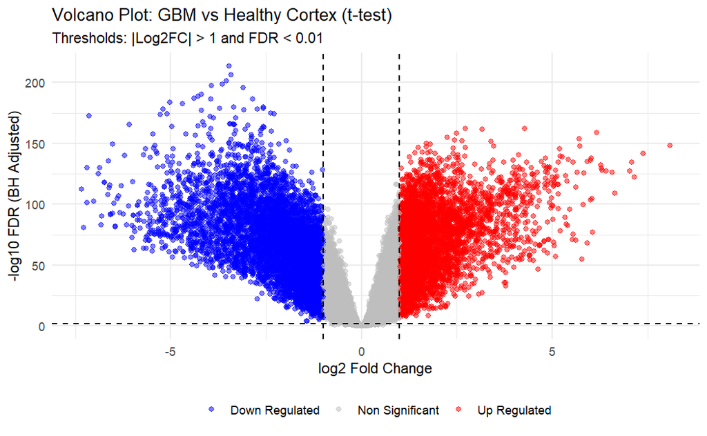

```r
results_ttest$direction <- with(results_ttest,
                                 ifelse(adj_p < 0.01 & log2FC > 1, "Up Regulated",
                                 ifelse(adj_p < 0.01 & log2FC < -1, "Down Regulated", "Non Significant")))

ggplot(results_ttest, aes(x = log2FC, y = -log10(adj_p), color = direction)) +
  geom_point(alpha = 0.5, size = 1.5) +
  scale_color_manual(values = c("Down Regulated" = "blue",
                                "Non Significant" = "grey",
                                "Up Regulated" = "red")) +
  theme_minimal() +

  geom_vline(xintercept = c(-1, 1), linetype = "dashed", color = "black") +
  geom_hline(yintercept = -log10(0.01), linetype = "dashed", color = "black") +


  labs(title = "Volcano Plot: GBM vs Healthy Cortex (t-test)",
       subtitle = "Thresholds: |Log2FC| > 1 and FDR < 0.01",
       x = "log2 Fold Change",
       y = "-log10 FDR (BH Adjusted)") +

  theme(legend.title = element_blank(),
        legend.position = "bottom")
```

In this volcano plot, genes on the right side are up-regulated in GBM, while genes on the left side are down-regulated compared to healthy cortex. Genes located higher in the plot show stronger statistical significance, whereas genes lower in the plot are less significant.

Red and blue points in the upper left and upper right regions represent genes with both large expression changes and strong statistical support. Gray points near the center or bottom indicate genes that do not meet the chosen thresholds for differential expression.

### 4.2.2. EdgeR Approach

The use of generalized linear models (GLMs) in edgeR allows us to model biological variability (overdispersion) inherent in RNA-seq data, overcoming the limitations of simple t-tests.

**Create a Design Matrix**

We first define the experimental groups (GTEx = healthy baseline, TCGA = tumor) and build a design matrix. The design matrix specifies which comparison will be tested by the GLM.

```r
# 1. Initialize DGEList object
group <- factor(pca_df$Group, levels = c("GTEx", "TCGA"))
dge <- DGEList(counts = count_matrix, group = group)

# 2. Assign groups and filter lowly expressed genes
keep <- filterByExpr(dge, group = group)
dge <- dge[keep, , keep.lib.sizes = FALSE]

cat("Genes before filtering:", nrow(count_matrix), "\n")
```

```
Genes before filtering: 63856
```

```r
cat("Genes after filtering :", nrow(dge), "\n")
```

```
Genes after filtering : 25065
```

```r
# 3. Normalization and Design Matrix
dge <- calcNormFactors(dge, method = "TMM")
design <- model.matrix(~ group)
colnames(design) <- c("Intercept", "TCGA_vs_GTEx")

head(design)
```

```
  Intercept TCGA_vs_GTEx
1         1            0
2         1            0
3         1            0
4         1            0
5         1            0
6         1            0
```

After filtering, approximately 25,000 genes are retained for differential expression analysis. These genes show sufficient expression across samples to allow reliable estimation of dispersion and statistical testing.

**Dispersion Estimation**

RNA-seq count data show greater variability than expected under a simple Poisson model, due to biological differences between samples. Dispersion estimation quantifies this extra variability (overdispersion).

edgeR estimates dispersion at multiple levels:

- **Common dispersion** captures the overall biological variability shared across all genes.

- **Trended dispersion** models how variability depends on gene expression level.

- **Tagwise dispersion** provides gene-specific dispersion estimates, borrowing strength across genes to improve robustness.

```r
# 1. Estimate Common Dispersion (Usually fast)
print("Estimating common dispersion...")
```

```
[1] "Estimating common dispersion..."
```

```r
dge <- estimateCommonDisp(dge, design)

# 2. Estimate Trended Dispersion (This is what usually takes time)
print("Estimating trended dispersion...")
```

```
[1] "Estimating trended dispersion..."
```

```r
dge <- estimateGLMTrendedDisp(dge, design)

# 3. Estimate Tagwise Dispersion (Final step)
print("Estimating tagwise dispersion...")
```

```
[1] "Estimating tagwise dispersion..."
```

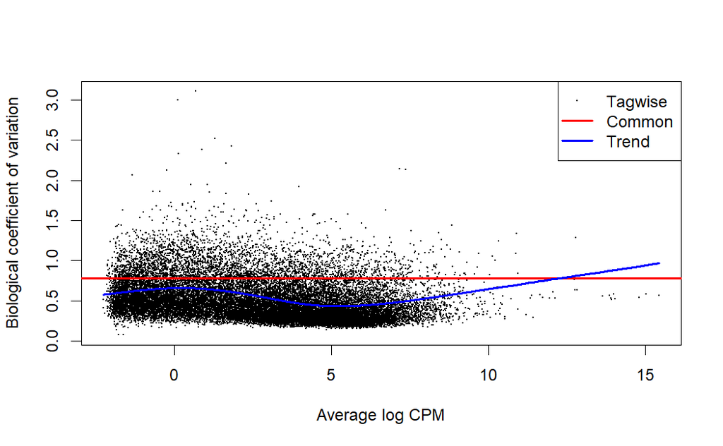

```r
dge <- estimateGLMTagwiseDisp(dge, design)


# Visualize the BCV
plotBCV(dge)
```

The BCV (Biological Coefficient of Variation) plot shows the relationship between gene expression level (average log-CPM) and biological variability. Each point represents a gene, while the blue line indicates the trended dispersion and the red line the common dispersion.

**GLM Fitting and Likelihood Ratio Test (LRT)**

After estimating dispersions, we fit a generalized linear model (GLM) to the count data. The GLM models gene expression as a function of the experimental design, incorporating both normalization factors and dispersion estimates.

```r
# Now that dispersions are estimated, we can fit the model
fit <- glmFit(dge, design)
lrt <- glmLRT(fit, coef = 2)

# 6. Extract results
results_edgeR <- as.data.frame(topTags(lrt, n = Inf))
results_edgeR$is_significant <- results_edgeR$FDR < 0.001 & abs(results_edgeR$logFC) > 1

head(results_edgeR)
```

|  | logFC | logCPM | LR | PValue | FDR | is_significant |
| --- | --- | --- | --- | --- | --- | --- |
| ENSG00000128713.13 | 8.900387 | 0.7307056 | 1565.618 | 0 | 0 | TRUE |
| ENSG00000128710.5 | 8.642669 | 1.5069463 | 1544.702 | 0 | 0 | TRUE |
| ENSG00000254369.6 | 8.346670 | 2.1046801 | 1545.358 | 0 | 0 | TRUE |
| ENSG00000131747.14 | 7.900606 | 4.9988807 | 1895.085 | 0 | 0 | TRUE |
| ENSG00000101057.15 | 7.811655 | 3.6278497 | 2769.327 | 0 | 0 | TRUE |
| ENSG00000168078.9 | 7.799900 | 2.9743092 | 2631.193 | 0 | 0 | TRUE |

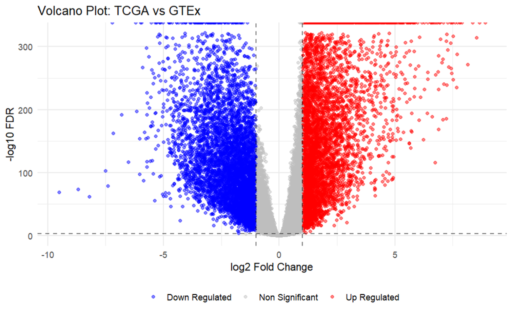

```r
# Extract results (using 'lrt' instead of 'lrt.BvsL')
results_edgeR <- as.data.frame(topTags(lrt, n = Inf))

# Add significance labels
results_edgeR$direction <- with(results_edgeR,
                                 ifelse(FDR < 0.001 & logFC > 1, "Up Regulated",
                                 ifelse(FDR < 0.001 & logFC < -1, "Down Regulated",
                                 "Non Significant")))

# Create Volcano Plot
ggplot(results_edgeR, aes(x = logFC, y = -log10(FDR), color = direction)) +
  geom_point(alpha = 0.5, size = 1.2) +
  scale_color_manual(values = c("Non Significant" = "grey",
                                "Up Regulated" = "red",
                                "Down Regulated" = "blue")) +
  theme_minimal() +
  # Add threshold lines
  geom_vline(xintercept = c(-1, 1), linetype = "dashed", alpha = 0.5) +
  geom_hline(yintercept = -log10(0.001), linetype = "dashed", alpha = 0.5) +
  labs(title = "Volcano Plot: TCGA vs GTEx",
       x = "log2 Fold Change",
       y = "-log10 FDR") +
  theme(legend.position = "bottom", legend.title = element_blank())
```

**Retrieve Gene Names**

```r
# Convert results to dataframe
results <- as.data.frame(topTags(lrt, n = Inf))
head(results)
```

|  | logFC | logCPM | LR | PValue | FDR |
| --- | --- | --- | --- | --- | --- |
| ENSG00000128713.13 | 8.900387 | 0.7307056 | 1565.618 | 0 | 0 |
| ENSG00000128710.5 | 8.642669 | 1.5069463 | 1544.702 | 0 | 0 |
| ENSG00000254369.6 | 8.346670 | 2.1046801 | 1545.358 | 0 | 0 |
| ENSG00000131747.14 | 7.900606 | 4.9988807 | 1895.085 | 0 | 0 |
| ENSG00000101057.15 | 7.811655 | 3.6278497 | 2769.327 | 0 | 0 |
| ENSG00000168078.9 | 7.799900 | 2.9743092 | 2631.193 | 0 | 0 |

```r
# Clean Ensembl IDs by removing version suffix
clean_ids <- gsub("\\..*", "", rownames(results))

# Map IDs to SYMBOL
results$SYMBOL <- mapIds(org.Hs.eg.db,
                         keys = clean_ids,
                         column = "SYMBOL",
                         keytype = "ENSEMBL",
                         multiVals = "first")

# Map IDs to GENENAME
results$GENENAME <- mapIds(org.Hs.eg.db,
                           keys = clean_ids,
                           column = "GENENAME",
                           keytype = "ENSEMBL",
                           multiVals = "first")

# Check the first few rows of the annotated results
head(results)
```

|  | logFC | logCPM | LR | PValue | FDR | SYMBOL | GENENAME |
| --- | --- | --- | --- | --- | --- | --- | --- |
| ENSG00000128713.13 | 8.900387 | 0.7307056 | 1565.618 | 0 | 0 | HOXD11 | homeobox D11 |
| ENSG00000128710.5 | 8.642669 | 1.5069463 | 1544.702 | 0 | 0 | HOXD10 | homeobox D10 |
| ENSG00000254369.6 | 8.346670 | 2.1046801 | 1545.358 | 0 | 0 | HOXA-AS3 | HOXA cluster antisense RNA 3 |
| ENSG00000131747.14 | 7.900606 | 4.9988807 | 1895.085 | 0 | 0 | TOP2A | DNA topoisomerase II alpha |
| ENSG00000101057.15 | 7.811655 | 3.6278497 | 2769.327 | 0 | 0 | MYBL2 | MYB proto-oncogene like 2 |
| ENSG00000168078.9 | 7.799900 | 2.9743092 | 2631.193 | 0 | 0 | PBK | PDZ binding kinase |

We annotate the edgeR output by mapping Ensembl IDs to gene symbols and gene names. This improves interpretability in downstream plots and biological interpretation.

**Find the gene symbols of the genes tested**

```r
# Map IDs to gene names (SYMBOL and GENENAME) for all tested genes
gene_annotations <- AnnotationDbi::select(org.Hs.eg.db,
                                          keys = gsub("\\..*", "", rownames(dge)),
                                          columns = c("SYMBOL", "GENENAME"),
                                          keytype = "ENSEMBL")

# View the result
head(gene_annotations)
```

|  | ENSEMBL | SYMBOL | GENENAME |
| --- | --- | --- | --- |
| 1 | ENSG00000278267 | MIR6859-1 | microRNA 6859-1 |
| 2 | ENSG00000227232 | NA | NA |
| 3 | ENSG00000243485 | NA | NA |
| 4 | ENSG00000238009 | NA | NA |
| 5 | ENSG00000233750 | CICP27 | capicua transcriptional repressor pseudogene 27 |
| 6 | ENSG00000268903 | NA | NA |

**Overlapping set of DEGs (Upset Plot)**

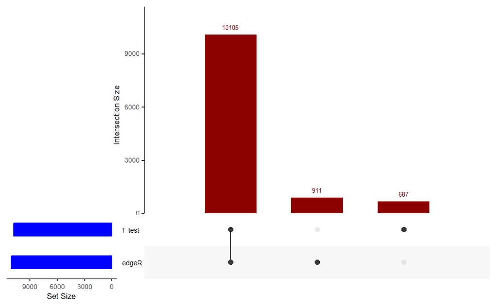

```r
de_ttest <- results_ttest[results_ttest$adj_p < 0.001 & abs(results_ttest$log2FC) > 1, ]
genes_ttest <- de_ttest$gene

de_edgeR_fair <- results[results$FDR < 0.001 & abs(results$logFC) > 1, ]
genes_edgeR <- rownames(de_edgeR_fair)

gene_lists <- list("T-test" = genes_ttest, "edgeR" = genes_edgeR)

UpSetR::upset(UpSetR::fromList(gene_lists),
              nsets = 2,
              order.by = "freq",
              main.bar.color = "darkred",
              sets.bar.color = "blue")
```

The UpSet plot shows a substantial overlap between the genes identified as differentially expressed by the naive t-test and by edgeR. The large intersection indicates strong agreement between the two methods, while the method-specific sets highlight genes whose significance depends on the underlying statistical model.

In particular, a large intersection (≈10,000 genes) is detected by both the naive t-test and edgeR, indicating strong agreement in identifying the main transcriptional differences between GBM and healthy cortex.

**Function enrichment analysis on the genes we obtain through edgeR**

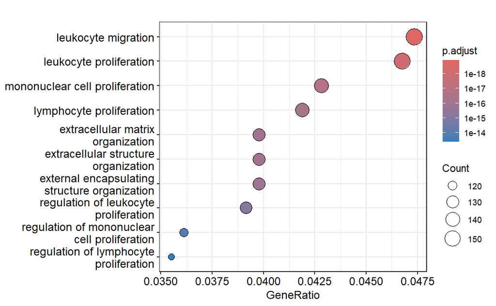

```r
upregulated_edgeR <- rownames(results[results$FDR < 0.001 & results$logFC > 1, ])
upregulated_clean <- gsub("\\..*", "", upregulated_edgeR)

# Perform GO enrichment analysis
ego <- enrichGO(gene          = upregulated_clean,
                OrgDb         = org.Hs.eg.db,
                keyType       = "ENSEMBL",
                ont           = "BP",
                pAdjustMethod = "BH",
                pvalueCutoff  = 0.05,
                qvalueCutoff  = 0.2,
                readable      = TRUE)

# View the results
dotplot(ego, showCategory=10)
```

The GO enrichment analysis highlights a strong activation of immune-related processes, including leukocyte migration and lymphocyte proliferation, suggesting extensive immune involvement in GBM tissue. Additionally, enrichment of extracellular matrix organization terms indicates tissue remodeling and invasive tumor behavior. Overall, these results reflect hallmark features of glioblastoma biology.

**Visualize same results with the network**

To conclude the functional interpretation, we visualize the enriched GO Biological Process terms as a network. In our case, a standard enrichment map (e.g., `emapplot`) becomes difficult to read due to the high number of terms and connections. For this reason, we use **visNetwork**, which provides an interactive network (zoom, drag, search and hover tooltips), making it easier to explore functional modules and term-to-term relationships.

For more details, see the official documentation: https://cran.r-project.org/web/packages/visNetwork/vignettes/Introduction-to-visNetwork.html

```r
# --- SETTINGS ---
n_top <- 40; threshold <- 0.2

# 1. Process Data & Colors
res <- as.data.frame(ego) %>% top_n(n_top, -p.adjust)
pal <- colorRampPalette(c("#e41a1c", "#377eb8"))(100)
res$col <- pal[as.numeric(cut(-log10(res$p.adjust), 100))]

# 2. Compute term similarity BEFORE accessing it
ego <- pairwise_termsim(ego)

# 2. Nodes & Links
nodes <- data.frame(id=res$Description, label=res$Description,
                    value=res$Count/2, color=res$col,
                    title = paste0("<b>Term:</b> ", res$Description, "<br>",
                                   "<b>p.adj:</b> ", formatC(res$p.adjust, format="e", 2), "<br>",
                                   "<b>Count:</b> ", res$Count))

sim <- ego@termsim[nodes$id, nodes$id]
links <- data.frame(which(sim > threshold & lower.tri(sim), arr.ind=T)) %>%
  rename(from=row, to=col) %>%
  mutate(from=rownames(sim)[from], to=colnames(sim)[to], width=sim[cbind(from,to)]*2)

# 3. Plot
visNetwork(nodes, links, main="GO Interaction Map") %>%
  visNodes(font=list(size=25, strokeWidth=5, strokeColor="white")) %>%
  visEdges(color=list(color="grey", opacity=0.2)) %>%
  visOptions(highlightNearest=T, nodesIdSelection=list(enabled=T, values=nodes$id)) %>%
  visPhysics(solver="forceAtlas2Based", forceAtlas2Based=list(gravitationalConstant=-150))
```

[interactive chart not shown]

The interactive GO interaction network reveals that enriched biological processes cluster into a few major functional modules, indicating coordinated biological programs altered in GBM.

The first major module is related to **immune cell migration and chemotaxis**, including leukocyte migration, granulocyte migration, and cell chemotaxis. This cluster highlights strong immune cell recruitment and infiltration in the tumor microenvironment, a known feature of glioblastoma.

A second prominent module involves **immune cell proliferation and differentiation**, particularly T cell, lymphocyte, and mononuclear cell proliferation. This suggests active regulation of immune cell expansion and differentiation, reflecting an inflamed and immunologically dynamic tumor context.

The third functional module is associated with **cell cycle and chromosome segregation**, including mitotic nuclear division and sister chromatid segregation. This cluster reflects increased proliferative activity and dysregulated cell division, which are hallmarks of aggressive tumor growth.

Overall, the network representation highlights how immune-related processes and tumor-intrinsic proliferative programs are tightly interconnected in GBM, providing a systems-level view of the biological mechanisms underlying the observed differential gene expression.

# 5. Protein-Protein Interaction (PPI) Network analysis

## 5.1 Seed Selection

Genes do not act in isolation, but their protein products interact in complex networks to carry out cellular functions. Differential gene expression analysis identifies genes associated with the disease condition, but does not provide information on how these genes interact at the protein level.

Protein–Protein Interaction (PPI) networks allow the integration of transcriptomic results with proteomic knowledge, enabling the identification of key proteins (hubs), functional modules, and dysregulated biological pathways involved in the disease. This network-based approach follows the principles of network medicine, where disease-associated genes tend to cluster into connected subnetworks (disease modules).

```r
library(STRINGdb)
library(igraph)
library(clusterProfiler)
library(org.Hs.eg.db)
library(enrichplot)
library(tidyverse)
```

```r
deg_idx <- which(
  results_edgeR$FDR < 0.05 &
  abs(results_edgeR$logFC) > 1
)

deg_genes <- rownames(results_edgeR)[deg_idx]

length(deg_genes)
```

```
[1] 11017
```

```r
head(deg_genes)
```

```
[1] "ENSG00000128713.13" "ENSG00000128710.5"  "ENSG00000254369.6"  "ENSG00000131747.14" "ENSG00000101057.15"
[6] "ENSG00000168078.9"
```

Differentially expressed genes were selected using an edgeR-based analysis, applying a false discovery rate (FDR) threshold of 0.05 and an absolute log2 fold change greater than 1 , in order to focus the PPI network analysis on biologically relevant genes

```r
deg_genes_clean <- sub("\\..*$", "", deg_genes)
head(deg_genes_clean)
```

```
[1] "ENSG00000128713" "ENSG00000128710" "ENSG00000254369" "ENSG00000131747" "ENSG00000101057" "ENSG00000168078"
```

## 5.2 ID processing

Gene identifiers were originally annotated using Ensembl IDs including version numbers. Version information was removed to ensure compatibility with downstream annotation databases.

```r
gene_mapping <- bitr(
  deg_genes_clean,
  fromType = "ENSEMBL",
  toType   = "SYMBOL",
  OrgDb    = org.Hs.eg.db
)

head(gene_mapping)
```

|  | ENSEMBL | SYMBOL |
| --- | --- | --- |
| 1 | ENSG00000128713 | HOXD11 |
| 2 | ENSG00000128710 | HOXD10 |
| 3 | ENSG00000254369 | HOXA-AS3 |
| 4 | ENSG00000131747 | TOP2A |
| 5 | ENSG00000101057 | MYBL2 |
| 6 | ENSG00000168078 | PBK |

```r
deg_symbols <- unique(gene_mapping$SYMBOL)

length(deg_symbols)
```

```
[1] 8325
```

```r
head(deg_symbols)
```

```
[1] "HOXD11"   "HOXD10"   "HOXA-AS3" "TOP2A"    "MYBL2"    "PBK"
```

Since differential expression analysis is gene-based while protein–protein interaction networks operate at the protein level, Ensembl gene identifiers were cleaned and converted to gene symbols to ensure correct mapping and biological interpretation.

```r
string_db <- STRINGdb$new(
  version = "11.5",
  species = 9606,
  score_threshold = 700,
  input_directory = ""
)
```

```r
mapped_genes <- string_db$map(
  data.frame(gene = deg_symbols),
  "gene",
  removeUnmappedRows = TRUE
)
nrow(mapped_genes)
```

```
[1] 6717
```

```r
head(mapped_genes)
```

|  | gene | STRING_id |
| --- | --- | --- |
| 1 | HOXD11 | 9606.ENSP00000249504 |
| 2 | HOXD10 | 9606.ENSP00000249501 |
| 3 | TOP2A | 9606.ENSP00000411532 |
| 4 | MYBL2 | 9606.ENSP00000217026 |
| 5 | PBK | 9606.ENSP00000428489 |
| 6 | HOXA6 | 9606.ENSP00000222728 |

We restricted the analysis to high-confidence protein–protein interactions to reduce false positives and we have obtained a list of human proteins, derived from DEGs, mapped to STRING

## 5.3 PPI Construction

```r
ppi_edges <- string_db$get_interactions(mapped_genes$STRING_id)
ppi_graph <- graph_from_data_frame(
  ppi_edges[, c("from", "to")],
  directed = FALSE
)
```

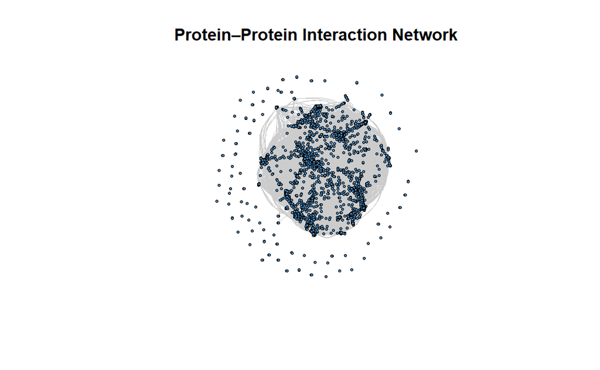

```r
plot(
  ppi_graph,
  vertex.label = NA,
  vertex.size = 3,
  edge.color = "grey80",
  vertex.color = "steelblue",
  main = "Protein–Protein Interaction Network"
)
```

The complete PPI network is shown to illustrate the overall connectivity structure. Due to network size, individual nodes are not labeled, and subsequent analyses focus on topological and functional properties

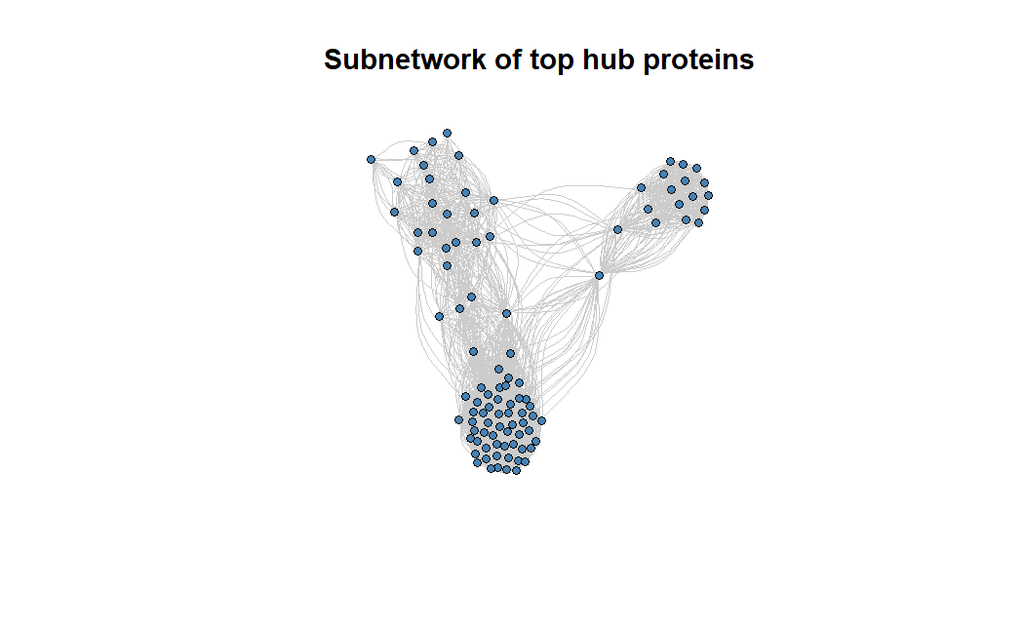

```r
deg <- degree(ppi_graph)

top_nodes <- names(sort(deg, decreasing = TRUE)[1:100])
sub_ppi <- induced_subgraph(ppi_graph, top_nodes)

plot(
  sub_ppi,
  vertex.label = NA,
  vertex.size = 5,
  edge.color = "grey80",
  vertex.color = "steelblue",
  main = "Subnetwork of top hub proteins"
)
```

To improve interpretability, a subnetwork composed of the most highly connected proteins was extracted from the full PPI network. This visualization highlights a densely interconnected core of hub proteins, suggesting the presence of central functional modules within the disease-associated network.

```r
network_density <- edge_density(ppi_graph)
avg_degree <- mean(deg)

network_density
```

```
[1] 0.005961251
```

```r
avg_degree
```

```
[1] 32.00596
```

The PPI network shows a low overall density, as expected for biological interaction networks, with an average node degree consistent with the presence of highly connected hub proteins.

## 5.4 Network topology analysis

```r
deg <- degree(ppi_graph)
bet <- betweenness(ppi_graph)
```

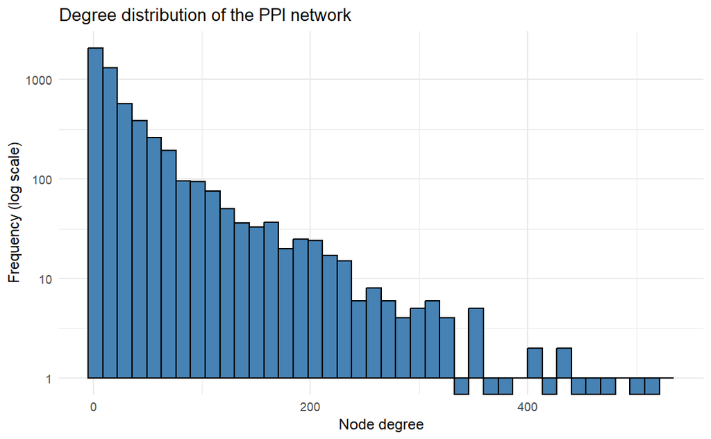

```r
deg_df <- data.frame(degree = deg)

ggplot(deg_df, aes(x = degree)) +
  geom_histogram(bins = 40, fill = "steelblue", color = "black") +
  scale_y_log10() +
  theme_minimal() +
  labs(
    title = "Degree distribution of the PPI network",
    x = "Node degree",
    y = "Frequency (log scale)"
  )
```

The degree distribution of the PPI network is highly right-skewed, indicating a scale-free topology characterized by a small number of highly connected hub proteins and many low-degree nodes, which is a typical feature of biological networks

```r
library(poweRlaw)

m <- displ$new(deg_df$degree)

est_xmin <- estimate_xmin(m)
m$setXmin(est_xmin)

est_pars <- estimate_pars(m)
m$setPars(est_pars$pars)
```

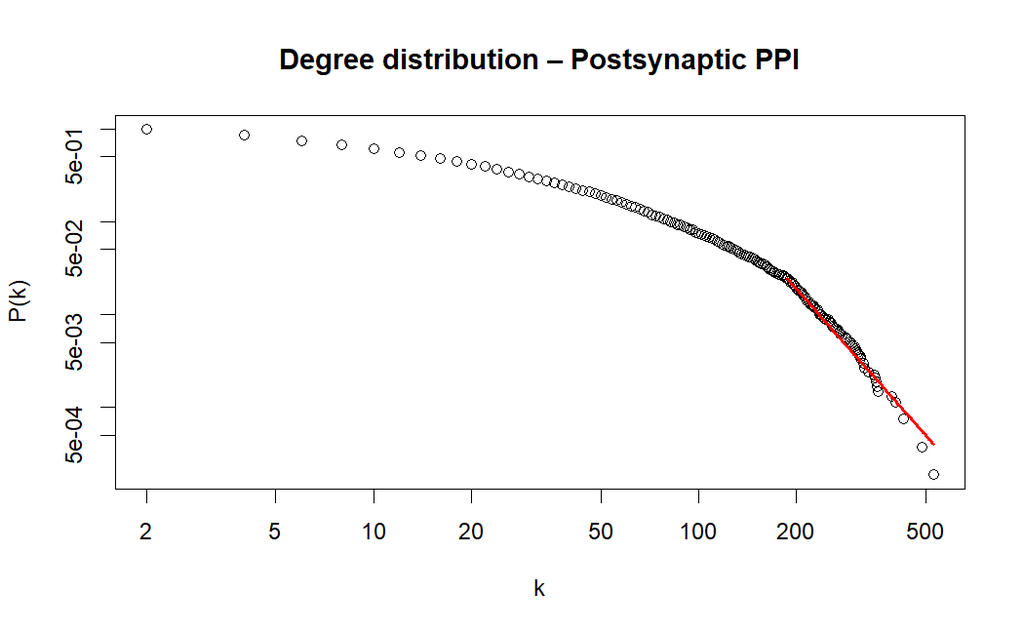

```r
plot(
  m,
  main = "Degree distribution – Postsynaptic PPI",
  xlab = "k",
  ylab = "P(k)",
  col = "black"
)

# power-law
lines(m, col = "red", lwd = 2)
```

```r
top_hubs <- sort(deg, decreasing = TRUE)[1:10]
top_hubs
```

```
9606.ENSP00000269305 9606.ENSP00000378699 9606.ENSP00000344456 9606.ENSP00000388107 9606.ENSP00000256442 9606.ENSP00000275493
                 528                  486                  428                  428                  404                  404
9606.ENSP00000274026 9606.ENSP00000383118 9606.ENSP00000349960 9606.ENSP00000400175
                 394                  356                  354                  352
```

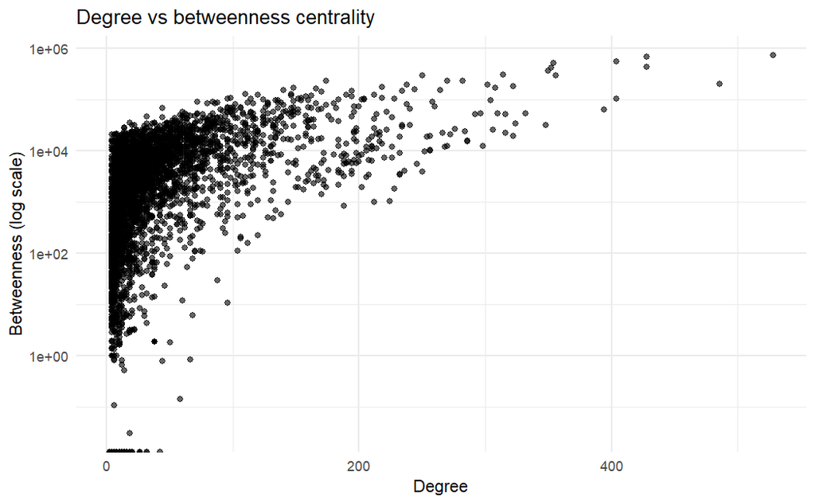

```r
centrality_df <- data.frame(
  protein = names(deg),
  degree = deg,
  betweenness = bet
)

ggplot(centrality_df, aes(x = degree, y = betweenness)) +
  geom_point(alpha = 0.6) +
  scale_y_log10() +
  theme_minimal() +
  labs(
    title = "Degree vs betweenness centrality",
    x = "Degree",
    y = "Betweenness (log scale)"
  )
```

While hub proteins are characterized by a high number of interactions, proteins with high betweenness centrality act as connectors between different regions of the network and may coordinate distinct functional modules.

## 5.5 Community detection

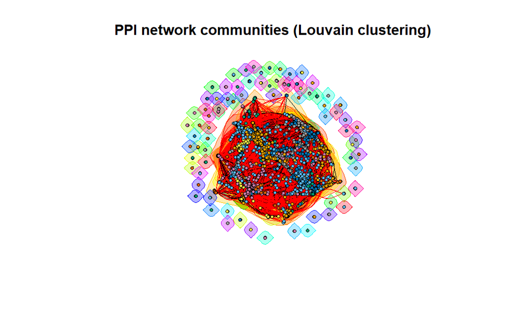

```r
communities <- cluster_louvain(ppi_graph)

plot(
  communities,
  ppi_graph,
  vertex.label = NA,
  vertex.size = 4,
  main = "PPI network communities (Louvain clustering)"
)
```

Community detection was performed using the Louvain algorithm, a modularity-based method designed for large-scale networks. In biological interaction networks, this approach allows the identification of functional modules, which are thought to represent disease-associated subnetworks according to the principles of network medicine [Blondel et al., 2008; Barabási et al., 2011].

The different colors indicate different identified communities, so the network is not a random cluster but rather groups of proteins connected to each other, captured mainly by a nucleus interconnected with other smaller peripheral groups.

```r
components_ppi <- components(ppi_graph)

table(components_ppi$csize)[1:5]
```

```
 2  3  4  5  6
54 16  3  1  1
```

```r
largest_comp_size <- max(components_ppi$csize)
largest_comp_size
```

```
[1] 5191
```

Most proteins in the PPI network belong to a single large connected component, suggesting the presence of a coherent disease-associated module rather than isolated interactions.

## 5.6 Functional Enrichment

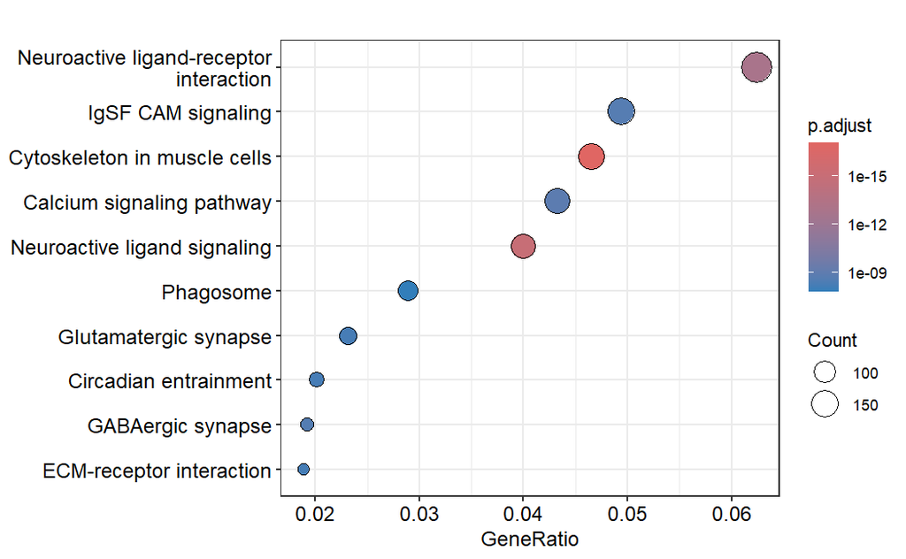

```r
entrez_ids <- bitr(
  mapped_genes$gene,
  fromType = "SYMBOL",
  toType = "ENTREZID",
  OrgDb = org.Hs.eg.db
)

kegg_enrich <- enrichKEGG(
  gene = entrez_ids$ENTREZID,
  organism = "hsa",
  pvalueCutoff = 0.05
)

dotplot(kegg_enrich, showCategory = 10)
```

Functional enrichment analysis of the PPI network revealed significant over-representation of signaling pathways related to cell communication, calcium signaling, and extracellular matrix interactions. Although some KEGG pathways are annotated as neuronal, they include general signaling components such as receptors and ion channels that are also active in non-neuronal tissues, including cancer. Overall, these results support the biological relevance of the identified PPI network and highlight dysregulated signaling processes associated with the disease.

# 6. Single-Cell RNA-seq Analysis

## 6.1. Introduction and Data Loading

To complement our bulk RNA-seq analysis comparing healthy brain cortex (GTEx) with glioblastoma (TCGA), we now perform single-cell RNA-seq analysis. This allows us to:

- Identify specific cell types present in brain cortex tissue
- Examine cell-type-specific expression patterns
- Provide cellular context for the bulk RNA-seq findings
- Discover heterogeneous cell populations in cortex tissue

**Rationale for using mouse cortex data:**

We initially selected the “hu-cortex-2017” dataset from the scRNAseq Bioconductor package, assuming it contained human cortex data based on the dataset name. However, after downloading and analyzing the data, we discovered that this is actually a **mouse cortex dataset** (the “hu” prefix is misleading).

While ideally we would use human scRNA-seq data to match our bulk RNA-seq analysis, this cross-species approach still provides valuable insights into cortical cellular heterogeneity and demonstrates competency in single-cell data analysis techniques.

We begin by searching the scRNAseq package for available cortex datasets.

```r
# Search for cortex-related datasets
brain_datasets <- searchDatasets("cortex")
cat("Brain/Cortex datasets available:\n")
```

```
Brain/Cortex datasets available:
```

```r
print(brain_datasets[, c("name", "title", "version", "path", "description")])
```

```
DataFrame with 8 rows and 5 columns
                    name                  title     version        path            description
             <character>            <character> <character> <character>            <character>
1         hu-cortex-2017 Dissecting cell-type..  2023-12-20      cortex Dissecting cell-type..
2       tasic-brain-2016 Adult mouse cortical..  2024-04-18          NA Adult mouse cortical..
3  zhong-prefrontal-2018 A single-cell RNA-se..  2023-12-22          NA A single-cell RNA-se..
4 nowakowski-cortex-2017 Spatiotemporal gene ..  2023-12-22          NA Spatiotemporal gene ..
5                 legacy Adult mouse cortical..  2023-12-18       allen Adult mouse cortical..
6                 legacy Low-coverage single-..  2023-12-18    fluidigm Low-coverage single-..
7      zeisel-brain-2015 Brain structure. Cel..  2023-12-14          NA Brain structure. Cel..
8  bhaduri-organoid-2020 Cell stress in corti..  2023-12-21          NA Cell stress in corti..
```

```r
# Check available paths for this dataset
name <- "hu-cortex-2017"
version <- "2023-12-20"

cat("Available paths for", name, ":\n")
```

```
Available paths for hu-cortex-2017 :
```

```r
available_paths <- listPaths(name, version)
print(available_paths)
```

```
[1] "3T3"    "cortex"
```

```r
# Fetch the dataset
path = "cortex"
cortex_sc <- fetchDataset(name,version,path)
cortex_sc
```

```
class: SingleCellExperiment
dim: 19936 42500
metadata(0):
assays(1): counts
rownames(19936): 0610006L08Rik 0610007P14Rik ... mt-Tm n-R5-8s1
rowData names(0):
colnames(42500): ATTGTAATAAGC ACTTGTCCCAGG ... AGGTTCACGTAA TGTGAGAAGGAA
colData names(2): treatment animal
reducedDimNames(0):
mainExpName: NULL
altExpNames(0):
```

The dataset is loaded as a SingleCellExperiment object containing gene expression counts for individual cells.

## 6.2. Data Preparation and Quality Control

Before analysis, we need to check the quality of our cells and remove low-quality ones. Poor quality cells can arise from dead or dying cells, doublets (two cells captured together), or technical artifacts.

```r
# View available metadata columns
cat("Available metadata columns:\n")
```

```
Available metadata columns:
```

```r
metadata_cols <- colnames(colData(cortex_sc))
print(metadata_cols)
```

```
[1] "treatment" "animal"
```

```r
# Display metadata content
cat("\nMetadata content:\n")
```

```
Metadata content:
```

```r
head(colData(cortex_sc))
```

```
DataFrame with 6 rows and 2 columns
               treatment    animal
             <character> <integer>
ATTGTAATAAGC          NA         1
ACTTGTCCCAGG          NA         1
CCACCTTTTAAN          NA         1
ACAGAAATATCA          NA         1
CCACCCAACTGN          NA         1
CCAGTCGTATAN          NA         1
```

```r
cat("=== Dataset Metadata Summary ===\n\n")
```

```
=== Dataset Metadata Summary ===
```

```r
cat("Available columns:", length(metadata_cols), "\n")
```

```
Available columns: 2
```

```r
cat("Columns:", paste(metadata_cols, collapse = ", "), "\n\n")
```

```
Columns: treatment, animal
```

```r
# Check protocol column
if("protocol" %in% metadata_cols) {
  cat("Protocol values:\n")
  print(table(cortex_sc$protocol))
}

cat("\n**Note:** This dataset does not include pre-annotated cell types.\n")
```

```
**Note:** This dataset does not include pre-annotated cell types.
```

```r
cat("We will identify cell types through unsupervised clustering and marker gene analysis.\n")
```

```
We will identify cell types through unsupervised clustering and marker gene analysis.
```

```r
print(cortex_sc)
```

```
class: SingleCellExperiment
dim: 19936 42500
metadata(0):
assays(1): counts
rownames(19936): 0610006L08Rik 0610007P14Rik ... mt-Tm n-R5-8s1
rowData names(0):
colnames(42500): ATTGTAATAAGC ACTTGTCCCAGG ... AGGTTCACGTAA TGTGAGAAGGAA
colData names(2): treatment animal
reducedDimNames(0):
mainExpName: NULL
altExpNames(0):
```

```r
cat("\nNumber of genes:", nrow(cortex_sc), "\n")
```

```
Number of genes: 19936
```

```r
cat("Number of cells:", ncol(cortex_sc), "\n")
```

```
Number of cells: 42500
```

**Objective:** The scRNA-seq dataset was downloaded as a SingleCellExperiment object. Before performing downstream single-cell analysis (normalization, dimensionality reduction, clustering), the data must be converted into a Seurat object, which requires:

- A standard sparse count matrix
- Unique gene (feature) names
- Unique cell identifiers
- Proper integration of cell-level metadata

We first verify which assays are available in the dataset and confirm the presence of raw counts.

```r
# List available assays
assays(cortex_sc)
```

```
List of length 1
names(1): counts
```

```r
# Access the raw counts matrix
assay(cortex_sc, "counts")
```

```
<19936 x 42500> sparse DelayedMatrix object of type "integer":
              ATTGTAATAAGC ACTTGTCCCAGG CCACCTTTTAAN ACAGAAATATCA ... ATTCGACGATTC ATGTACTGCGGG AGGTTCACGTAA TGTGAGAAGGAA
0610006L08Rik            0            0            0            0   .            0            0            0            0
0610007P14Rik            3            0            0            1   .            0            0            0            1
0610009B22Rik            0            0            1            0   .            0            0            0            0
0610009E02Rik            0            0            0            0   .            0            0            0            0
0610009L18Rik            0            0            0            0   .            0            0            0            0
          ...            .            .            .            .   .            .            .            .            .
       mt-Nd6            0            0            0            0   .            0            0            0            0
      mt-Rnr1            0            1            0            0   .            1            0            0            0
      mt-Rnr2            5            8           10            8   .            4            2            1            0
        mt-Tm            0            0            0            0   .            0            0            0            0
     n-R5-8s1            1            3            1            0   .            0            0            0            0
```

```r
colnames(rowData(cortex_sc))
```

```
character(0)
```

```r
head(rowData(cortex_sc))
```

```
DataFrame with 6 rows and 0 columns
```

No gene-level metadata is provided (rowData is empty), meaning gene identifiers are stored directly as row names in the count matrix.

```r
# Extract raw counts
counts <- assay(cortex_sc, "counts")

# Convert to standard sparse matrix
counts <- as(counts, "dgCMatrix")
```

```r
# Make feature (gene) names unique
rownames(counts) <- make.unique(rownames(counts))

# Make cell names unique
colnames(counts) <- make.unique(colnames(counts))
```

```r
so <- CreateSeuratObject(
  counts = counts,
  project = "hu_cortex_2017_cortex"
)

so
```

```
An object of class Seurat
19936 features across 42500 samples within 1 assay
Active assay: RNA (19936 features, 0 variable features)
 1 layer present: counts
```

The Seurat object is now created and ready for analysis. It stores the count matrix along with metadata for each cell.

```r
meta <- as.data.frame(colData(cortex_sc))
rownames(meta) <- colnames(counts)

so <- AddMetaData(so, metadata = meta)

head(so@meta.data)
```

|  | orig.ident | nCount_RNA | nFeature_RNA | treatment | animal |
| --- | --- | --- | --- | --- | --- |
| ATTGTAATAAGC | hu_cortex_2017_cortex | 21015 | 5579 | NA | 1 |
| ACTTGTCCCAGG | hu_cortex_2017_cortex | 25129 | 5441 | NA | 1 |
| CCACCTTTTAAN | hu_cortex_2017_cortex | 25437 | 5463 | NA | 1 |
| ACAGAAATATCA | hu_cortex_2017_cortex | 28982 | 5910 | NA | 1 |
| CCACCCAACTGN | hu_cortex_2017_cortex | 18527 | 4834 | NA | 1 |
| CCAGTCGTATAN | hu_cortex_2017_cortex | 24947 | 5805 | NA | 1 |

```r
NA
NA
```

```r
head(rownames(so))
```

```
[1] "0610006L08Rik" "0610007P14Rik" "0610009B22Rik" "0610009E02Rik" "0610009L18Rik" "0610009O20Rik"
```

```r
# Calculate percentage of mitochondrial genes
so[["percent.mt"]] <- PercentageFeatureSet(so, pattern = "^mt-")

# View updated metadata
head(so@meta.data)
```

|  | orig.ident | nCount_RNA | nFeature_RNA | treatment | animal | percent.mt |
| --- | --- | --- | --- | --- | --- | --- |
| ATTGTAATAAGC | hu_cortex_2017_cortex | 21015 | 5579 | NA | 1 | 0.033309541 |
| ACTTGTCCCAGG | hu_cortex_2017_cortex | 25129 | 5441 | NA | 1 | 0.035815194 |
| CCACCTTTTAAN | hu_cortex_2017_cortex | 25437 | 5463 | NA | 1 | 0.039312812 |
| ACAGAAATATCA | hu_cortex_2017_cortex | 28982 | 5910 | NA | 1 | 0.031053758 |
| CCACCCAACTGN | hu_cortex_2017_cortex | 18527 | 4834 | NA | 1 | 0.032385168 |
| CCAGTCGTATAN | hu_cortex_2017_cortex | 24947 | 5805 | NA | 1 | 0.008016996 |

High mitochondrial gene percentage often indicates dying cells, as damaged cells leak cytoplasmic RNA while retaining mitochondrial RNA.

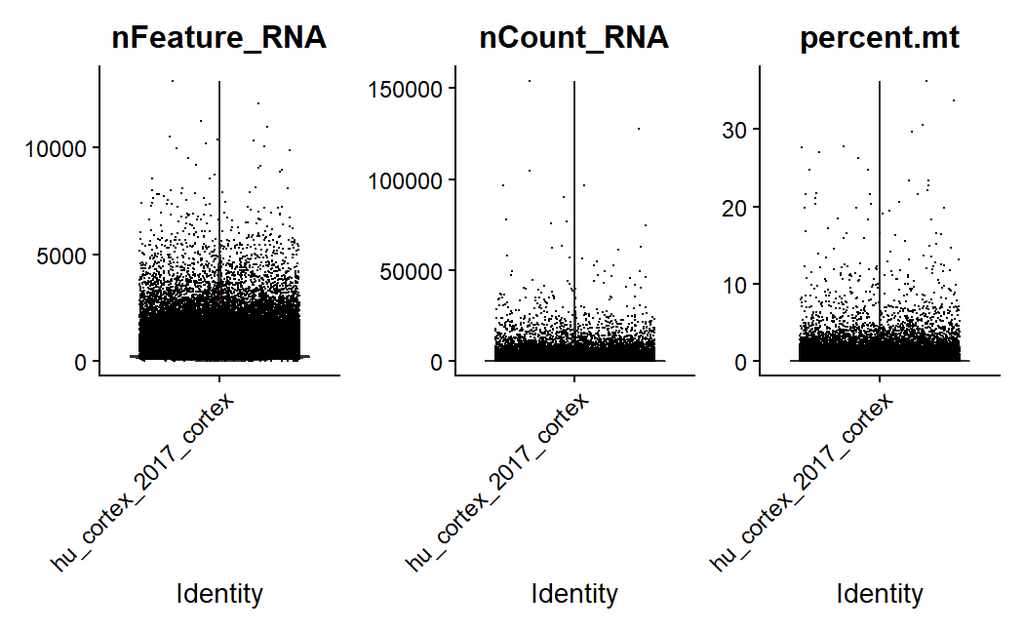

```r
# Violin plots for quality control metrics
VlnPlot(so, features = c("nFeature_RNA", "nCount_RNA", "percent.mt"),
        ncol = 3, pt.size = 0.1)
```

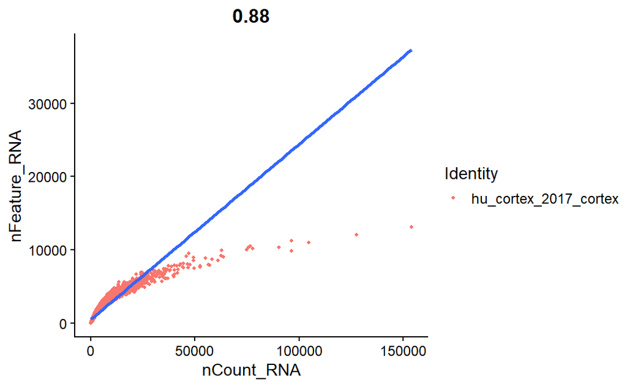

```r
# Scatter plot to examine relationship between total counts and detected genes
FeatureScatter(so, feature1 = "nCount_RNA", feature2 = "nFeature_RNA") +
  geom_smooth(method = "lm")
```

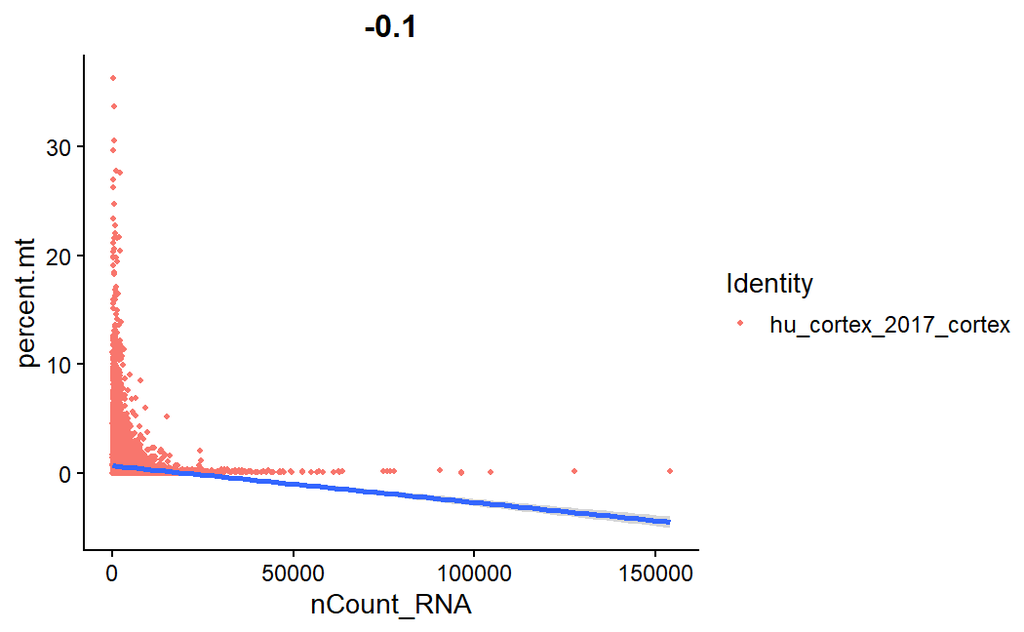

```r
# Scatter plot for mitochondrial content vs gene count
FeatureScatter(so, feature1 = "nCount_RNA", feature2 = "percent.mt") +
  geom_smooth(method = "lm")
```

```r
NA
NA
```

```r
# Filter based on QC metrics
# Adjust thresholds based on your violin plots
so <- subset(so, subset = nFeature_RNA > 200 &
                          nFeature_RNA < 2500 &
                          percent.mt < 5)

cat("Cells after filtering:", ncol(so), "\n")
```

```
Cells after filtering: 33890
```

```r
cat("Genes:", nrow(so), "\n")
```

```
Genes: 19936
```

After filtering, we retain only high-quality cells for downstream analysis. Cells with too few or too many detected genes, or high mitochondrial content, have been removed.

## 6.3. Normalization and Feature Selection

Normalize the raw gene expression data to enable meaningful comparison between cells. The `NormalizeData()` function applies log-normalization:

$$\text{Normalized}_{ij} = \log_1p \left(
\frac{\text{Counts}_{ij}}{\sum_{k} \text{Counts}_{kj}} \times 10000
\right)$$

This corrects for differences in sequencing depth between cells while preserving biological differences.

```r
# Log-normalize the data
so <- NormalizeData(so,
                    normalization.method = "LogNormalize",
                    scale.factor = 10000)
cat("Normalization complete.\n")
```

```
Normalization complete.
```

```r
cat("Normalized data stored in 'data' layer.\n")
```

```
Normalized data stored in 'data' layer.
```

Identify genes that show high cell-to-cell variation. These genes are most informative for distinguishing cell types and will be used for downstream analysis.

```r
# Find variable features using variance stabilizing transformation
so <- FindVariableFeatures(so,
                           selection.method = "vst",
                           nfeatures = 2000)
# Identify the top 10 most variable genes
top10_var <- head(VariableFeatures(so), 10)
cat("Top 10 most variable genes:\n")
```

```
Top 10 most variable genes:
```

```r
print(top10_var)
```

```
 [1] "Plp1"    "Adarb2"  "Slc13a3" "Usp24"   "Vip"     "Sst"     "Npy"     "Ptgds"   "Gpc5"    "Hbb-bs"
```

We select 2,000 highly variable genes for downstream analysis. These genes show the most variation across cells and are most useful for distinguishing different cell types.

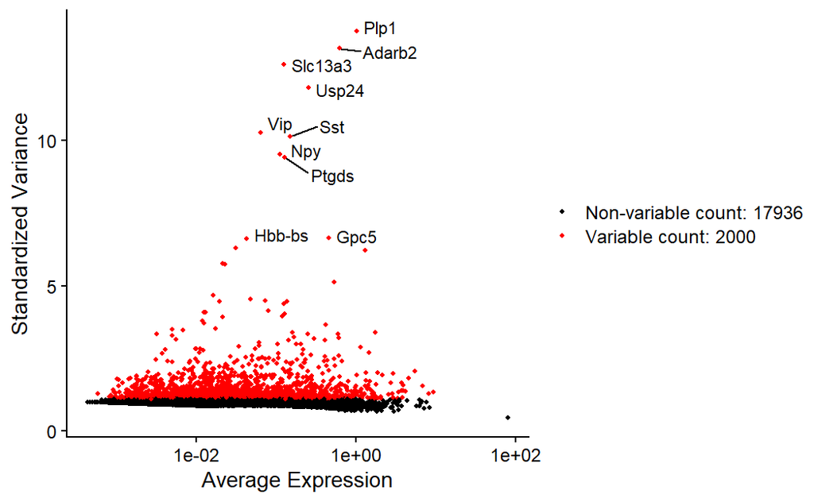

```r
# Plot variable features
plot1 <- VariableFeaturePlot(so)
plot2 <- LabelPoints(plot = plot1, points = top10_var, repel = TRUE)
plot2
```

Scaling standardizes gene expression values by centering (subtracting the mean) and scaling (dividing by standard deviation). This ensures that highly expressed genes do not dominate downstream analyses.

```r
# Scale all genes
all_genes <- rownames(so)
so <- ScaleData(so, features = all_genes)
cat("Scaling complete.\n")
```

```
Scaling complete.
```

```r
cat("Scaled data dimensions:", dim(so[["RNA"]]$scale.data), "\n")
```

```
Scaled data dimensions: 19936 33890
```

## 6.4. Dimensionality Reduction (PCA)

Principal Component Analysis (PCA) reduces the dimensionality of the data while preserving the most important sources of variation.

```r
# Run PCA on variable features
so <- RunPCA(so, features = VariableFeatures(object = so))

# View PCA results
print(so[["pca"]], dims = 1:5, nfeatures = 5)
```

```
PC_ 1
Positive:  Plp1, Mal, Mag, Mog, Cldn11
Negative:  Kcnd2, Lrfn5, Gm26871, Sntg1, Kcnq5
PC_ 2
Positive:  Neat1, Mag, Mal, Mog, Dock10
Negative:  Kcnip4, Gm28928, Nrg1, Kcnh7, Tenm2
PC_ 3
Positive:  Mag, Mog, Mal, St18, Aspa
Negative:  Atp1a2, Slc1a3, Mertk, Ptprz1, Slco1c1
PC_ 4
Positive:  Rorb, Slc1a2, Car10, Gm28928, Atp1a2
Negative:  Gad2, Gad1, Erbb4, Nxph1, Grip1
PC_ 5
Positive:  Hs3st4, Foxp2, Zfpm2, Garnl3, Cdh18
Negative:  Lingo2, Fam19a1, Unc5d, Pde7b, Calb1
```

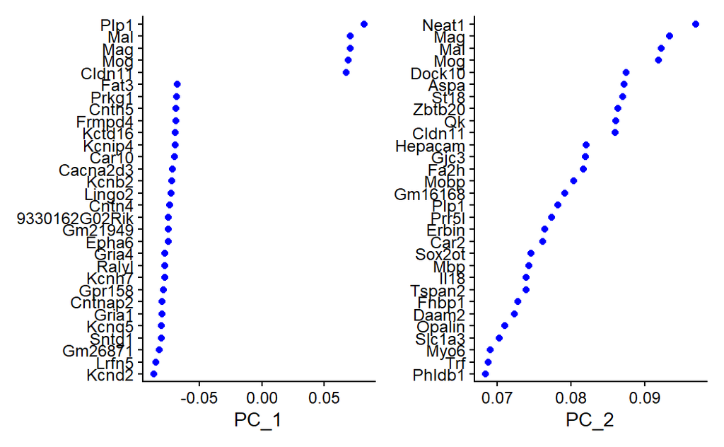

```r
# Visualize top genes contributing to PC1 and PC2
VizDimLoadings(so, dims = 1:2, reduction = "pca")
```

This plot shows the genes that contribute most to the first two principal components (PC1 and PC2). These genes are the main drivers of variation in the dataset and help explain the differences between cells observed in the PCA.

Mal, Mag, and Mog contribute strongly to both PC1 and PC2, suggesting that differences related to these genes play an important role in separating cells in the PCA.

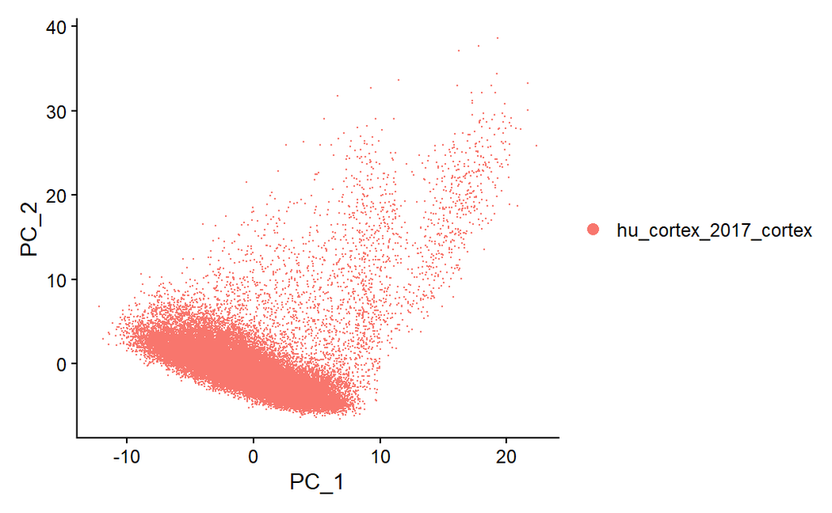

```r
# PCA plot
DimPlot(so, reduction = "pca")
```

The PCA plot shows that the cells are largely similar, with gradual variation rather than clearly separated groups

```r
print(so[["pca"]], dims = 1:5, nfeatures = 5)
```

```
PC_ 1
Positive:  Plp1, Mal, Mag, Mog, Cldn11
Negative:  Kcnd2, Lrfn5, Gm26871, Sntg1, Kcnq5
PC_ 2
Positive:  Neat1, Mag, Mal, Mog, Dock10
Negative:  Kcnip4, Gm28928, Nrg1, Kcnh7, Tenm2
PC_ 3
Positive:  Mag, Mog, Mal, St18, Aspa
Negative:  Atp1a2, Slc1a3, Mertk, Ptprz1, Slco1c1
PC_ 4
Positive:  Rorb, Slc1a2, Car10, Gm28928, Atp1a2
Negative:  Gad2, Gad1, Erbb4, Nxph1, Grip1
PC_ 5
Positive:  Hs3st4, Foxp2, Zfpm2, Garnl3, Cdh18
Negative:  Lingo2, Fam19a1, Unc5d, Pde7b, Calb1
```

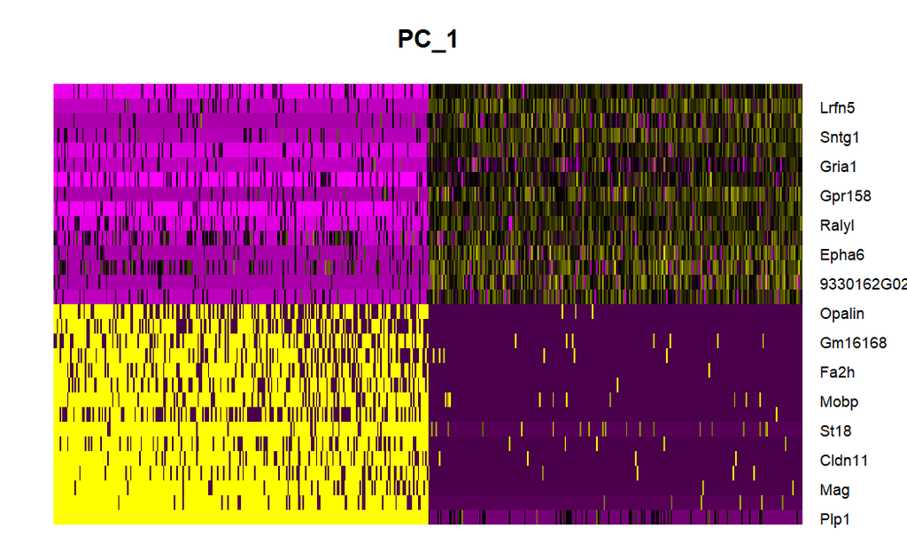

```r
# Heatmap of top genes in first principal component
DimHeatmap(so, dims = 1, cells = 500, balanced = TRUE)
```

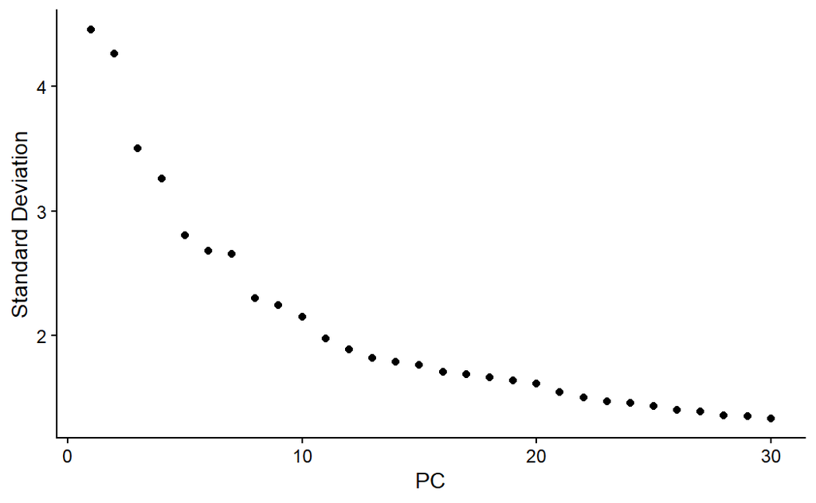

```r
# Elbow plot to determine optimal number of PCs
ElbowPlot(so, ndims = 30)
```

The elbow plot shows the variance explained by each PC. We look for the “elbow” point where adding more PCs provides diminishing returns.

## 6.5. Clustering and UMAP Visualization

Construct a shared nearest neighbor (SNN) graph to identify similar cells.

```r
# Find neighbors using selected PCs (adjust dims based on elbow plot)
so <- FindNeighbors(so, dims = 1:15)
```

Cluster cells using the Louvain algorithm at multiple resolutions to explore different granularities.

```r
# Cluster at multiple resolutions
so <- FindClusters(so, resolution = c(0.1, 0.3, 0.5, 0.8, 1.0))
```

```
Modularity Optimizer version 1.3.0 by Ludo Waltman and Nees Jan van Eck

Number of nodes: 33890
Number of edges: 999287

Running Louvain algorithm...
```

```
Maximum modularity in 10 random starts: 0.9552
Number of communities: 10
Elapsed time: 7 seconds
Modularity Optimizer version 1.3.0 by Ludo Waltman and Nees Jan van Eck

Number of nodes: 33890
Number of edges: 999287

Running Louvain algorithm...
```

```
Maximum modularity in 10 random starts: 0.9218
Number of communities: 14
Elapsed time: 7 seconds
Modularity Optimizer version 1.3.0 by Ludo Waltman and Nees Jan van Eck

Number of nodes: 33890
Number of edges: 999287

Running Louvain algorithm...
```

```
Maximum modularity in 10 random starts: 0.8999
Number of communities: 19
Elapsed time: 7 seconds
Modularity Optimizer version 1.3.0 by Ludo Waltman and Nees Jan van Eck

Number of nodes: 33890
Number of edges: 999287

Running Louvain algorithm...
```

```
Maximum modularity in 10 random starts: 0.8756
Number of communities: 22
Elapsed time: 7 seconds
Modularity Optimizer version 1.3.0 by Ludo Waltman and Nees Jan van Eck

Number of nodes: 33890
Number of edges: 999287

Running Louvain algorithm...
```

```
Maximum modularity in 10 random starts: 0.8617
Number of communities: 23
Elapsed time: 7 seconds
```

```r
# View clustering results in metadata
head(so@meta.data)
```

|  | orig.ident | nCount_RNA | nFeature_RNA | treatment | animal | percent.mt | RNA_snn_res.0.1 | RNA_snn_res.0.3 | RNA_snn_res.0.5 | RNA_snn_res.0.8 | RNA_snn_res.1 | seurat_clusters |
| --- | --- | --- | --- | --- | --- | --- | --- | --- | --- | --- | --- | --- |
| TTACTTCATCCG | hu_cortex_2017_cortex | 6081 | 2165 | NA | 1 | 0.19733596 | 4 | 7 | 12 | 13 | 15 | 15 |
| GTCGTTTTCAGC | hu_cortex_2017_cortex | 6289 | 2435 | NA | 1 | 0.07950390 | 0 | 2 | 2 | 2 | 12 | 12 |
| GTTTGCTCCATN | hu_cortex_2017_cortex | 5010 | 2282 | NA | 1 | 0.03992016 | 0 | 3 | 4 | 7 | 6 | 6 |
| TCTGCCGGTGGG | hu_cortex_2017_cortex | 4790 | 2192 | NA | 1 | 0.06263048 | 5 | 6 | 7 | 9 | 9 | 9 |
| TTAAAAACCATA | hu_cortex_2017_cortex | 5674 | 2256 | NA | 1 | 0.07049700 | 2 | 4 | 3 | 4 | 3 | 3 |
| CTCAGCGCTGAN | hu_cortex_2017_cortex | 4963 | 2078 | NA | 1 | 0.00000000 | 3 | 9 | 10 | 12 | 14 | 14 |

he resolution parameter controls how many clusters are identified. Lower resolution gives fewer, broader clusters; higher resolution gives more, finer clusters. We test multiple values to find the best balance:

```r
# Compare different resolutions
cat("Number of clusters at each resolution:\n")
```

```
Number of clusters at each resolution:
```

```r
cat("Resolution 0.1:", length(unique(so$RNA_snn_res.0.1)), "clusters\n")
```

```
Resolution 0.1: 10 clusters
```

```r
cat("Resolution 0.3:", length(unique(so$RNA_snn_res.0.3)), "clusters\n")
```

```
Resolution 0.3: 14 clusters
```

```r
cat("Resolution 0.5:", length(unique(so$RNA_snn_res.0.5)), "clusters\n")
```

```
Resolution 0.5: 19 clusters
```

```r
cat("Resolution 0.8:", length(unique(so$RNA_snn_res.0.8)), "clusters\n")
```

```
Resolution 0.8: 22 clusters
```

```r
cat("Resolution 1.0:", length(unique(so$RNA_snn_res.1)), "clusters\n")
```

```
Resolution 1.0: 23 clusters
```

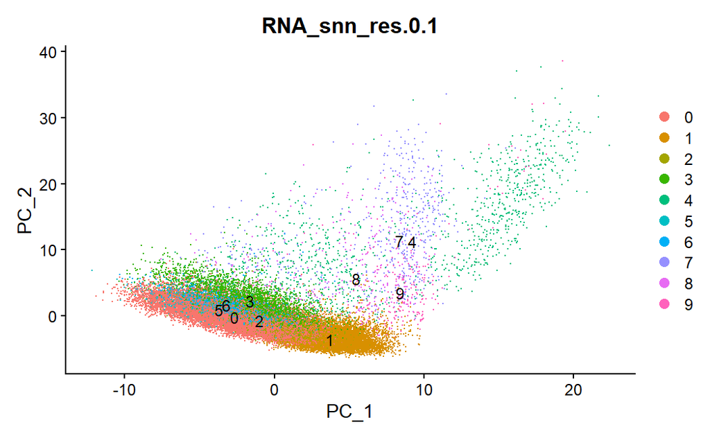

```r
DimPlot(so, reduction = "pca", group.by = "RNA_snn_res.0.1", label = TRUE)
```

```r
# Run UMAP
so <- RunUMAP(so, dims = 1:15)
```

```
Using method 'umap'
```

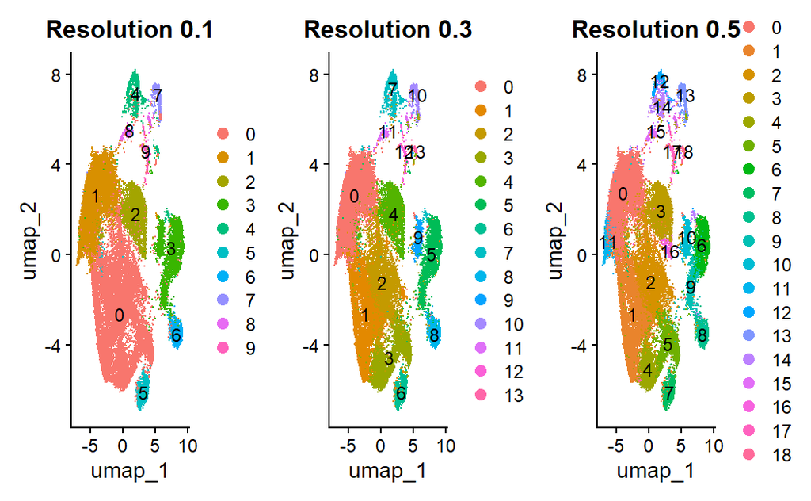

```r
# Compare clustering at different resolutions
p1 <- DimPlot(so, reduction = "umap", group.by = "RNA_snn_res.0.1", label = TRUE) +
  ggtitle("Resolution 0.1")
p2 <- DimPlot(so, reduction = "umap", group.by = "RNA_snn_res.0.3", label = TRUE) +
  ggtitle("Resolution 0.3")
p3 <- DimPlot(so, reduction = "umap", group.by = "RNA_snn_res.0.5", label = TRUE) +
  ggtitle("Resolution 0.5")

p1 + p2 + p3
```

Comparing different resolutions helps us choose the appropriate level of granularity. Lower resolutions merge similar cell types, while higher resolutions may split biological cell types into multiple clusters. we think that 0.3 it’s a good resolution

```r
# Set identity to resolution 0.3
Idents(so) <- "RNA_snn_res.0.3"

cat("Active identity set to resolution 0.3\n")
```

```
Active identity set to resolution 0.3
```

```r
cat("Number of clusters:", length(unique(Idents(so))), "\n")
```

```
Number of clusters: 14
```

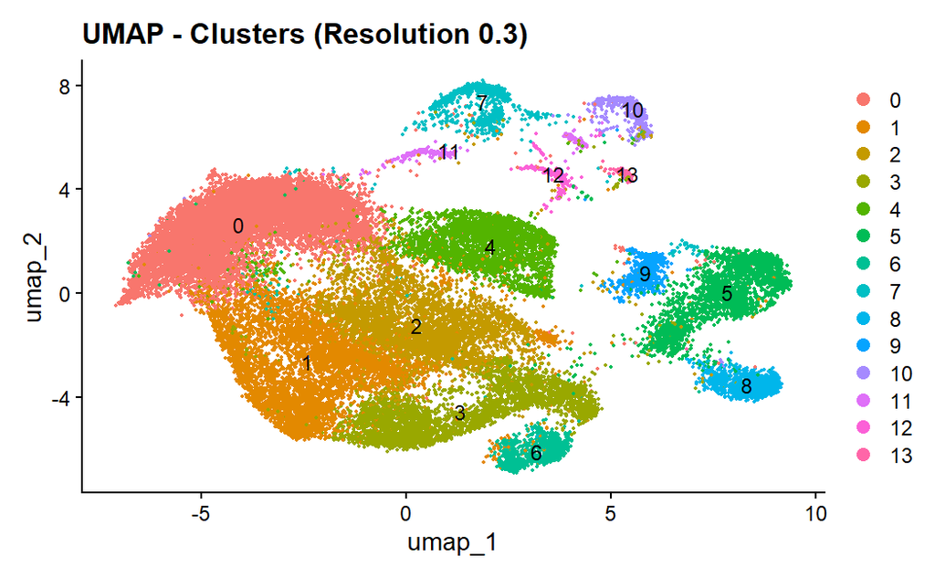

```r
# UMAP plot colored by cluster
DimPlot(so, reduction = "umap", label = TRUE, pt.size = 0.5) +
  ggtitle("UMAP - Clusters (Resolution 0.3)")
```

Resolution 0.3 was selected for downstream analysis, yielding 14 clusters. This resolution provides a balance between biological granularity and interpretability:

- **Major cell types are clearly separated** (large distinct clusters in different UMAP regions)
- **Rare cell populations are preserved** (small but distinct clusters 6, 10-13)
- **Avoids over-fragmentation** observed at higher resolutions (0.5: 19 clusters, 1.0: 23 clusters)
- **Matches expected cortical diversity**: Mouse cortex contains ~10-15 distinct cell types/states, including multiple neuronal subtypes, glial cells, and vascular cells

The UMAP visualization shows clear spatial segregation between major clusters, suggesting distinct transcriptional profiles consistent with different cell type identities.

## 6.6. Cell Type Annotation final

**Marker Gene Identification**

First, we identify the top marker genes for each cluster to understand the molecular characteristics of each cell population.

```r
# Find markers for all clusters
all_markers <- FindAllMarkers(so,
                               only.pos = TRUE,
                               min.pct = 0.25,
                               logfc.threshold = 0.25)
```

[output not shown]

[output cut: 1179 more lines]

[output not shown]

```r
# View top markers per cluster
top_markers <- all_markers %>%
  group_by(cluster) %>%
  slice_max(n = 5, order_by = avg_log2FC)

print(top_markers)
```

| p_val | avg_log2FC | pct.1 | pct.2 | p_val_adj | cluster | gene |
| --- | --- | --- | --- | --- | --- | --- |
| 8.031349e-08 | 1.0905012 | 0.466 | 0.658 | 1.601130e-03 | 0 | Gm42418 |
| 2.680635e-104 | 1.0789045 | 0.202 | 0.403 | 5.344114e-100 | 0 | Hsp90ab1 |
| 4.508592e-116 | 0.9870010 | 0.568 | 0.602 | 8.988329e-112 | 0 | Gm28928 |
| 8.985376e-124 | 0.9154093 | 0.123 | 0.273 | 1.791325e-119 | 0 | Basp1 |
| 2.223370e-115 | 0.9102408 | 0.206 | 0.419 | 4.432510e-111 | 0 | Nrgn |
| 0.000000e+00 | 1.9717809 | 0.302 | 0.058 | 0.000000e+00 | 1 | A830036E02Rik |
| 0.000000e+00 | 1.6253305 | 0.256 | 0.076 | 0.000000e+00 | 1 | Nectin3 |
| 0.000000e+00 | 1.4049031 | 0.528 | 0.199 | 0.000000e+00 | 1 | mt-Rnr1 |
| 1.881212e-273 | 1.1708970 | 0.302 | 0.122 | 3.750385e-269 | 1 | Arhgap15 |
| 2.103262e-269 | 1.0935561 | 0.322 | 0.136 | 4.193063e-265 | 1 | Nvl |

[output cut: 60 more lines]

The marker genes table shows which genes are specific to each cluster. These genes help us understand what cell type each cluster might represent.

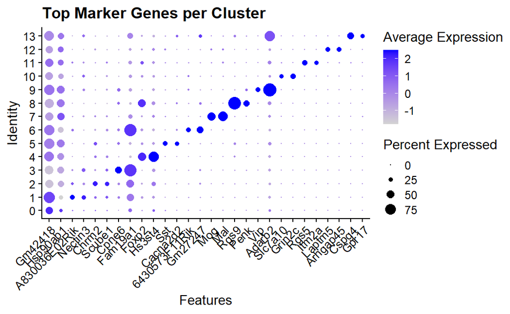

```r
# Get top 2 markers per cluster for visualization
top2_markers <- all_markers %>%
  group_by(cluster) %>%
  slice_max(n = 2, order_by = avg_log2FC) %>%
  pull(gene) %>%
  unique()

# Dot plot of top markers
DotPlot(so, features = top2_markers) +
  RotatedAxis() +
  ggtitle("Top Marker Genes per Cluster")
```

Other clusters (such as 2, 3, 4) show more distributed patterns, where marker genes are shared across multiple clusters with varying expression levels. This suggests these clusters may represent related cell subtypes or cells in transitional states. The combination of cluster-specific markers and the overall expression patterns supports the validity of the 14-cluster resolution and provides the foundation for identifying the biological identity of each cell population.

```r
# Load appropriate reference dataset (MouseRNAseqData for mouse cortex)
ref <- celldex::MouseRNAseqData()

# Convert Seurat to SingleCellExperiment
sce <- as.SingleCellExperiment(so)

# Run SingleR automatic annotation
predictions <- SingleR(test = sce,
                       ref = ref,
                       labels = ref$label.main)

# Add predictions to Seurat object
so$cell_type_auto <- predictions$labels

# View annotation summary
cat("Automatic cell type annotations:\n")
```

```
Automatic cell type annotations:
```

```r
print(table(so$cell_type_auto))
```

```
       Astrocytes           B cells Endothelial cells  Epithelial cells       Fibroblasts       Macrophages         Microglia
              451                 7                42                 4                14                 2               156
          Neurons          NK cells  Oligodendrocytes           T cells
            32680                 2               529                 3
```

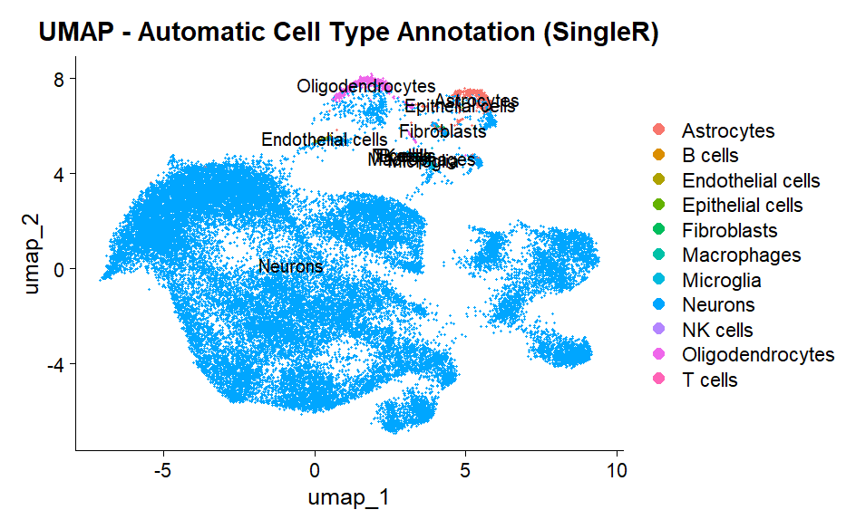

```r
# Visualize automatic annotations
DimPlot(so, reduction = "umap", group.by = "cell_type_auto", label = TRUE, pt.size = 0.5) +
  ggtitle("UMAP - Automatic Cell Type Annotation (SingleR)")
```

**Simplified Cell Type Categories**

To improve interpretability, we group similar cell types into broader categories.

```r
# Group similar cell types together
so$cell_type_simplified <- so$cell_type_auto

# Combine similar categories
so$cell_type_simplified <- gsub("Macrophages|Microglia", "Myeloid cells", so$cell_type_simplified)
so$cell_type_simplified <- gsub("B cells|T cells|NK cells", "Immune cells", so$cell_type_simplified)
so$cell_type_simplified <- gsub("Endothelial cells", "Endothelial", so$cell_type_simplified)
so$cell_type_simplified <- gsub("Epithelial cells", "Epithelial", so$cell_type_simplified)

# View simplified annotations
cat("\nSimplified cell type annotations:\n")
```

```
Simplified cell type annotations:
```

```r
print(table(so$cell_type_simplified))
```

```
      Astrocytes      Endothelial       Epithelial      Fibroblasts     Immune cells    Myeloid cells          Neurons
             451               42                4               14               12              158            32680
Oligodendrocytes
             529
```

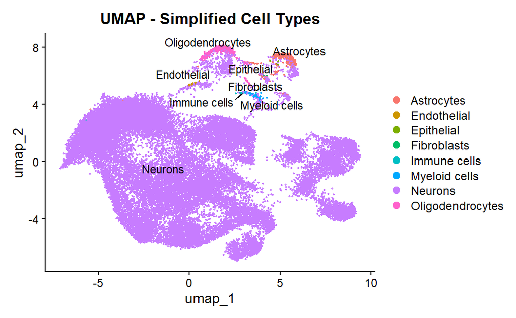

```r
# Plot simplified version
DimPlot(so, reduction = "umap", group.by = "cell_type_simplified",
        label = TRUE, repel = TRUE, pt.size = 0.5) +
  ggtitle("UMAP - Simplified Cell Types")
```

The simplified categories make it easier to interpret the data. The large purple area shows neurons, which make up most of the cells in the cortex. The smaller groups at the top represent supporting cells like oligodendrocytes (which help neurons transmit signals), astrocytes (which provide nutrients), and other cell types including immune and blood vessel cells. This distribution is exactly what we expect for brain cortex tissue.

**Cell Type Proportions**

Finally, we quantify the proportion of each cell type in our dataset. This gives us an overview of the cellular composition of the tissue.

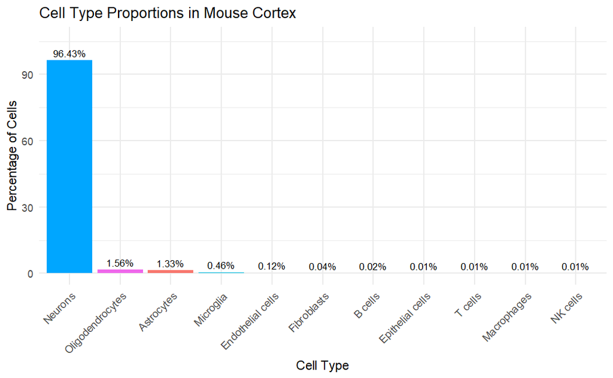

```r
# Calculate cell type proportions using detailed annotation
cell_type_counts <- table(so$cell_type_auto)
cell_type_props <- prop.table(cell_type_counts) * 100

# Create proportion dataframe
prop_df <- data.frame(
  CellType = names(cell_type_props),
  Proportion = as.numeric(cell_type_props)
)

# Plot cell type proportions with percentage labels
ggplot(prop_df, aes(x = reorder(CellType, -Proportion), y = Proportion, fill = CellType)) +
  geom_bar(stat = "identity") +
  geom_text(aes(label = paste0(round(Proportion, 2), "%")),
            vjust = -0.5, size = 3) +  # Add percentage labels
  theme_minimal() +
  theme(axis.text.x = element_text(angle = 45, hjust = 1),
        legend.position = "none") +
  labs(title = "Cell Type Proportions in Mouse Cortex",
       x = "Cell Type",
       y = "Percentage of Cells") +
  ylim(0, max(prop_df$Proportion) * 1.1)  # Add space at top for labels
```

This bar plot quantifies what we saw in the UMAP visualizations. Neurons make up over 96% of all cells, which is typical for cortex tissue. The remaining cells include oligodendrocytes (1.56%), astrocytes (1.33%), and microglia (0.46%) - all important supporting cells.

Other cell types like endothelial cells, immune cells, and fibroblasts are present in very small proportions (less than 0.2% each)

## 6.7. Enrichment Analysis of Cell-Type Marker Genes

**Gene Ontology (GO) Enrichment Analysis**

We perform GO enrichment analysis on the marker genes identified for each major cell type to understand the biological functions and processes associated with different cell populations.

```r
# First, load mouse annotation database
library(org.Mm.eg.db)

# Get unique cell types from the annotation
cell_types_to_analyze <- unique(so$cell_type_auto)

# Create a list to store enrichment results
enrichment_results <- list()

# Perform enrichment for each cell type
for (cell_type in cell_types_to_analyze) {

  # Get markers for this cell type
  cell_markers <- all_markers %>%
    filter(cluster %in% which(unique(so$cell_type_auto) == cell_type)) %>%
    pull(gene) %>%
    unique()

  cat("\nProcessing", cell_type, "with", length(cell_markers), "marker genes\n")

  if (length(cell_markers) > 10) {  # Only analyze if at least 10 markers

    # Convert mouse genes to ENTREZ IDs - USE MOUSE DATABASE (org.Mm.eg.db)
    tryCatch({
      entrez <- bitr(
        cell_markers,
        fromType = "SYMBOL",
        toType = "ENTREZID",
        OrgDb = org.Mm.eg.db  # CHANGED: Use mouse database for mouse genes
      )

      if (nrow(entrez) > 0) {
        cat("  -> Successfully mapped", nrow(entrez), "genes\n")

        # Perform GO enrichment with mouse database
        go_enrich <- enrichGO(
          gene = entrez$ENTREZID,
          OrgDb = org.Mm.eg.db,  # CHANGED: Use mouse database
          ont = "BP",
          pAdjustMethod = "BH",
          pvalueCutoff = 0.05,
          readable = TRUE
        )

        enrichment_results[[cell_type]] <- go_enrich

        cat("  -> Found", nrow(as.data.frame(go_enrich)), "enriched GO terms\n")
      } else {
        cat("  -> Could not map genes for", cell_type, "\n")
      }
    }, error = function(e) {
      cat("  -> Error processing", cell_type, ":", e$message, "\n")
    })
  } else {
    cat("  -> Skipping (fewer than 10 markers)\n")
  }
}
```

```
Processing Oligodendrocytes with 301 marker genes
  -> Successfully mapped 288 genes
  -> Found 291 enriched GO terms

Processing Neurons with 254 marker genes
  -> Successfully mapped 235 genes
  -> Found 379 enriched GO terms

Processing Astrocytes with 441 marker genes
  -> Successfully mapped 418 genes
  -> Found 510 enriched GO terms

Processing Microglia with 325 marker genes
  -> Successfully mapped 313 genes
  -> Found 456 enriched GO terms

Processing Macrophages with 417 marker genes
  -> Successfully mapped 394 genes
  -> Found 369 enriched GO terms

Processing Endothelial cells with 368 marker genes
  -> Successfully mapped 347 genes
  -> Found 299 enriched GO terms

Processing B cells with 262 marker genes
  -> Successfully mapped 251 genes
  -> Found 329 enriched GO terms

Processing Fibroblasts with 501 marker genes
  -> Successfully mapped 483 genes
  -> Found 639 enriched GO terms

Processing T cells with 380 marker genes
  -> Successfully mapped 359 genes
  -> Found 388 enriched GO terms

Processing NK cells with 330 marker genes
  -> Successfully mapped 319 genes
  -> Found 764 enriched GO terms

Processing Epithelial cells with 116 marker genes
  -> Successfully mapped 112 genes
  -> Found 204 enriched GO terms
```

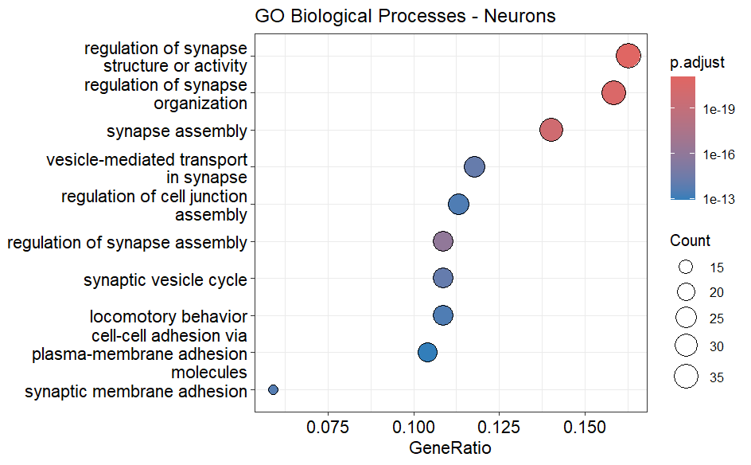

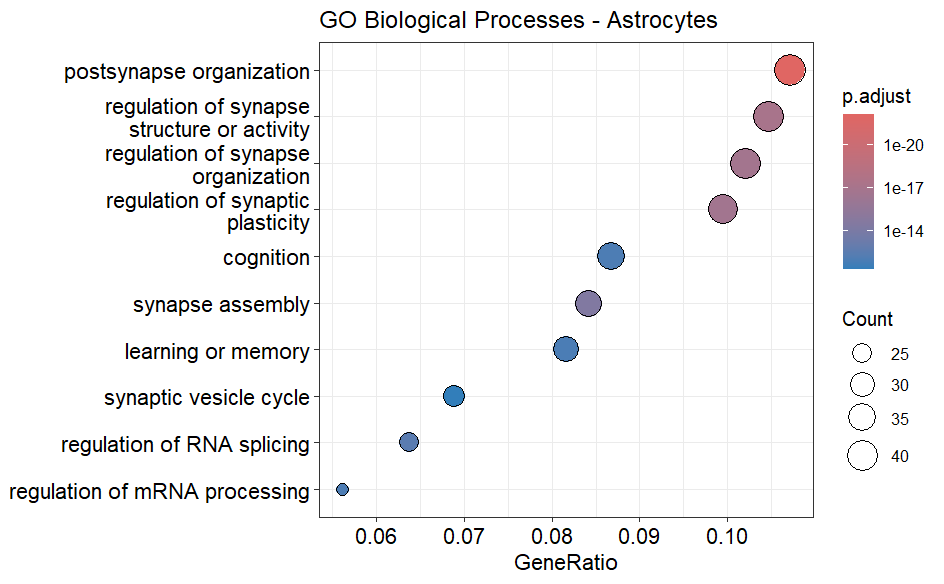

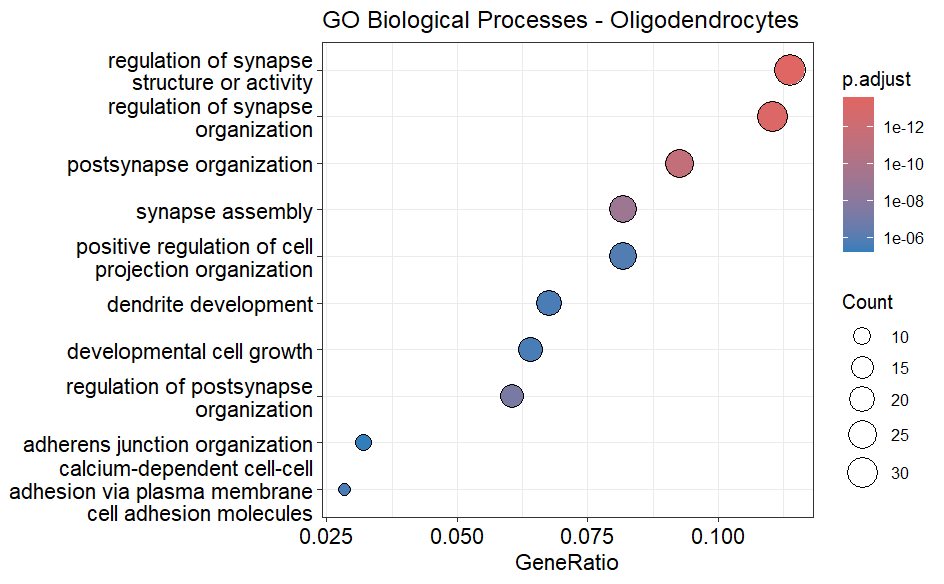

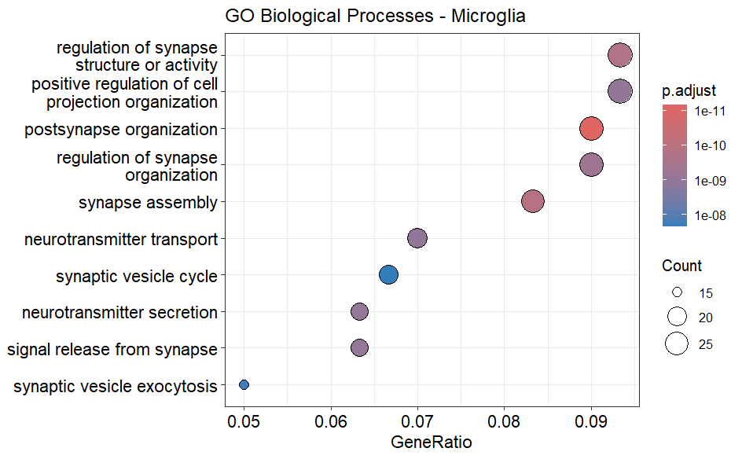

```r
# Add library for mouse organism database at the top
library(org.Mm.eg.db)

# Visualize enrichment results for major cell types
major_types <- c("Neurons", "Astrocytes", "Oligodendrocytes", "Microglia")

for (cell_type in major_types) {
  if (!is.null(enrichment_results[[cell_type]]) && nrow(as.data.frame(enrichment_results[[cell_type]])) > 0) {
    p <- dotplot(enrichment_results[[cell_type]], showCategory = 10) +
      ggtitle(paste("GO Biological Processes -", cell_type))
    print(p)
  }
}
```

**Neurons** Neuronal marker genes are mainly involved in synapse-related functions - forming connections between neurons and transmitting signals. The enrichment of vesicle transport and synaptic vesicle cycle confirms that these neurons are actively releasing neurotransmitters to communicate with other cells. This validates that we correctly identified neurons in our dataset.

**Astrocytes** Astrocyte marker genes are enriched for processes that support neuronal function, particularly organizing and regulating synapses. These cells help modulate how neurons communicate and are involved in cognitive processes and learning. This confirms astrocytes’ role as support cells that actively participate in brain function.

**Oligodendrocytes** Oligodendrocyte marker genes show enrichment for synapse organization and developmental processes. These cells support neurons by forming myelin sheaths, which help electrical signals travel faster along nerve fibers. The presence of cell adhesion terms reflects their close physical contact with neurons.

**Microglia** Microglia marker genes are enriched for synapse-related processes and neurotransmitter transport. This reflects their role as immune cells that monitor and maintain healthy synapses by removing damaged connections. These results confirm that microglia actively interact with and regulate neuronal circuits.

All major cell types show synapse-related enrichment, confirming that each population expresses genes consistent with their known biological roles in supporting neuronal communication.